# Bellabit marketing analysis

Macarena L. Fernandez Carro

2023-12-31

# PACKAGES

```r
## SET PACKAGES AND WORKING DIRECTORY

library(dplyr)
```

```r
library(ggplot2)
library(tidyr)
library(skimr)
library(lubridate)
library(egg)
library(forcats)
library(purrr)
library(readr)
library(stringr)
library(tibble)
library(here)
library(janitor)
library(viridis)
library(corrplot)
library(cowplot)
library(scales)
library(RColorBrewer)
library(waffle)
library(reshape)
library(reshape2)
library(ggrepel)
library(ggpubr)
```

# LOAD DATA

```r
## 1. Daily Data

daily_activity <- read.csv("dailyActivity_merged.csv")
daily_calories <- read.csv("dailyCalories_merged.csv")
daily_intensities <- read.csv("dailyIntensities_merged.csv")
daily_steps <- read.csv("dailySteps_merged.csv")


## 2. Hourly Data

hourly_calories <- read.csv("hourlyCalories_merged.csv")
hourly_intensities <- read.csv("hourlyIntensities_merged.csv")
hourly_steps <- read.csv("hourlySteps_merged.csv")

## 3. Minute Data

minute_calories_narrow <- read.csv("minuteCaloriesNarrow_merged.csv")
minute_calories_wide <- read.csv("minuteCaloriesWide_merged.csv")
minute_intensities_narrow <- read.csv("minuteIntensitiesNarrow_merged.csv")
minute_intensities_wide <- read.csv("minuteIntensitiesWide_merged.csv")
minute_METs_narrow <- read.csv("minuteMETsNarrow_merged.csv")
minute_sleep <- read.csv("minuteSleep_merged.csv")
minute_steps_narrow <- read.csv("minuteStepsNarrow_merged.csv")
minute_steps_wide <- read.csv("minuteStepsWide_merged.csv")

## 4. OTHER

heartrate_seconds <- read.csv("heartrate_seconds_merged.csv")
sleep_day <- read.csv("sleepDay_merged.csv")
weight <- read.csv("weightLogInfo_merged.csv")
```

##CHECK FOR DUPLICATES AND N/A VALUES

```r
## 1. Finding N/A values

any(is.na(daily_activity))
```

```
## [1] FALSE
```

```r
any(is.na(weight))
```

```
## [1] TRUE
```

```r
any(is.na(minute_METs_narrow))
```

```
## [1] FALSE
```

```r
any(is.na(sleep_day))
```

```
## [1] FALSE
```

```r
any(is.na(daily_calories))
```

```
## [1] FALSE
```

```r
any(is.na(heartrate_seconds))
```

```
## [1] FALSE
```

```r
any(is.na(minute_sleep))
```

```
## [1] FALSE
```

```r
any(is.na(minute_intensities_narrow))
```

```
## [1] FALSE
```

```r
any(is.na(minute_intensities_wide))
```

```
## [1] FALSE
```

```r
any(is.na(minute_calories_wide))
```

```
## [1] FALSE
```

```r
any(is.na(minute_calories_narrow))
```

```
## [1] FALSE
```

```r
any(is.na(hourly_intensities))
```

```
## [1] FALSE
```

```r
any(is.na(daily_intensities))
```

```
## [1] FALSE
```

```r
any(is.na(daily_steps))
```

```
## [1] FALSE
```

```r
any(is.na(hourly_steps))
```

```
## [1] FALSE
```

```r
any(is.na(minute_steps_wide))
```

```
## [1] FALSE
```

```r
any(is.na(minute_steps_narrow))
```

```
## [1] FALSE
```

```r
### weight does have N/A --> that column will be removed from analysis ###

## 2. Check in the Weights data were the N/A values are

any(is.na(weight$Date))
```

```
## [1] FALSE
```

```r
any(is.na(weight$WeightKg))
```

```
## [1] FALSE
```

```r
any(is.na(weight$WeightPounds))
```

```
## [1] FALSE
```

```r
any(is.na(weight$Fat))
```

```
## [1] TRUE
```

```r
any(is.na(weight$BMI))
```

```
## [1] FALSE
```

```r
any(is.na(weight$IsManualReport))
```

```
## [1] FALSE
```

```r
any(is.na(weight$LogId))
```

```
## [1] FALSE
```

```r
any(is.na(weight$Id))
```

```
## [1] FALSE
```

```r
### The column with N/a Values in weight is FAT. This column will not be used for analysis and there is no need to remove the NA values ###

## 3. Check for duplicates

sum(duplicated(daily_activity))
```

```
## [1] 0
```

```r
sum(duplicated(weight))
```

```
## [1] 0
```

```r
sum(duplicated(heartrate_seconds))
```

```
## [1] 0
```

```r
sum(duplicated(daily_calories))
```

```
## [1] 0
```

```r
sum(duplicated(hourly_calories))
```

```
## [1] 0
```

```r
sum(duplicated(minute_calories_narrow))
```

```
## [1] 0
```

```r
sum(duplicated(minute_calories_wide))
```

```
## [1] 0
```

```r
sum(duplicated(daily_intensities))
```

```
## [1] 0
```

```r
sum(duplicated(hourly_intensities))
```

```
## [1] 0
```

```r
sum(duplicated(minute_intensities_narrow))
```

```
## [1] 0
```

```r
sum(duplicated(minute_intensities_wide))
```

```
## [1] 0
```

```r
sum(duplicated(sleep_day))
```

```
## [1] 3
```

```r
sum(duplicated(minute_METs_narrow))
```

```
## [1] 0
```

```r
sum(duplicated(minute_steps_narrow))
```

```
## [1] 0
```

```r
sum(duplicated(minute_steps_wide))
```

```
## [1] 0
```

```r
sum(duplicated(hourly_steps))
```

```
## [1] 0
```

```r
sum(duplicated(daily_steps))
```

```
## [1] 0
```

```r
sum(duplicated(minute_sleep))
```

```
## [1] 543
```

```r
## 4. Remove duplicates and check the data

sleep_day_distinct <- sleep_day %>% distinct()
minute_sleep_distinct <- minute_sleep %>% distinct()

sum(duplicated(sleep_day_distinct))
```

```
## [1] 0
```

```r
sum(duplicated(minute_sleep_distinct))
```

```
## [1] 0
```

# TRANSFORMING DATA

```r
## 1. Removing columns that will not be used for analysis

daily_activity_transformed <- daily_activity %>%
  select(-c(TrackerDistance, LoggedActivitiesDistance))
head(daily_activity_transformed)
```

```
##           Id ActivityDate TotalSteps TotalDistance VeryActiveDistance
## 1 1503960366    4/12/2016      13162          8.50               1.88
## 2 1503960366    4/13/2016      10735          6.97               1.57
## 3 1503960366    4/14/2016      10460          6.74               2.44
## 4 1503960366    4/15/2016       9762          6.28               2.14
## 5 1503960366    4/16/2016      12669          8.16               2.71
## 6 1503960366    4/17/2016       9705          6.48               3.19
##   ModeratelyActiveDistance LightActiveDistance SedentaryActiveDistance
## 1                     0.55                6.06                       0
## 2                     0.69                4.71                       0
## 3                     0.40                3.91                       0
## 4                     1.26                2.83                       0
## 5                     0.41                5.04                       0
## 6                     0.78                2.51                       0
##   VeryActiveMinutes FairlyActiveMinutes LightlyActiveMinutes SedentaryMinutes
## 1                25                  13                  328              728
## 2                21                  19                  217              776
## 3                30                  11                  181             1218
## 4                29                  34                  209              726
## 5                36                  10                  221              773
## 6                38                  20                  164              539
##   Calories
## 1     1985
## 2     1797
## 3     1776
## 4     1745
## 5     1863
## 6     1728
```

```r
glimpse(daily_activity_transformed)
```

```
## Rows: 940
## Columns: 13
## $ Id                       <dbl> 1503960366, 1503960366, 1503960366, 150396036…
## $ ActivityDate             <chr> "4/12/2016", "4/13/2016", "4/14/2016", "4/15/…
## $ TotalSteps               <int> 13162, 10735, 10460, 9762, 12669, 9705, 13019…
## $ TotalDistance            <dbl> 8.50, 6.97, 6.74, 6.28, 8.16, 6.48, 8.59, 9.8…
## $ VeryActiveDistance       <dbl> 1.88, 1.57, 2.44, 2.14, 2.71, 3.19, 3.25, 3.5…
## $ ModeratelyActiveDistance <dbl> 0.55, 0.69, 0.40, 1.26, 0.41, 0.78, 0.64, 1.3…
## $ LightActiveDistance      <dbl> 6.06, 4.71, 3.91, 2.83, 5.04, 2.51, 4.71, 5.0…
## $ SedentaryActiveDistance  <dbl> 0, 0, 0, 0, 0, 0, 0, 0, 0, 0, 0, 0, 0, 0, 0, …
## $ VeryActiveMinutes        <int> 25, 21, 30, 29, 36, 38, 42, 50, 28, 19, 66, 4…
## $ FairlyActiveMinutes      <int> 13, 19, 11, 34, 10, 20, 16, 31, 12, 8, 27, 21…
## $ LightlyActiveMinutes     <int> 328, 217, 181, 209, 221, 164, 233, 264, 205, …
## $ SedentaryMinutes         <int> 728, 776, 1218, 726, 773, 539, 1149, 775, 818…
## $ Calories                 <int> 1985, 1797, 1776, 1745, 1863, 1728, 1921, 203…
```

```r
sleep_day_transformed <- sleep_day_distinct %>% select(-TotalSleepRecords)
head(sleep_day_transformed)
```

```
##           Id              SleepDay TotalMinutesAsleep TotalTimeInBed
## 1 1503960366 4/12/2016 12:00:00 AM                327            346
## 2 1503960366 4/13/2016 12:00:00 AM                384            407
## 3 1503960366 4/15/2016 12:00:00 AM                412            442
## 4 1503960366 4/16/2016 12:00:00 AM                340            367
## 5 1503960366 4/17/2016 12:00:00 AM                700            712
## 6 1503960366 4/19/2016 12:00:00 AM                304            320
```

```r
glimpse(sleep_day_transformed)
```

```
## Rows: 410
## Columns: 4
## $ Id                 <dbl> 1503960366, 1503960366, 1503960366, 1503960366, 150…
## $ SleepDay           <chr> "4/12/2016 12:00:00 AM", "4/13/2016 12:00:00 AM", "…
## $ TotalMinutesAsleep <int> 327, 384, 412, 340, 700, 304, 360, 325, 361, 430, 2…
## $ TotalTimeInBed     <int> 346, 407, 442, 367, 712, 320, 377, 364, 384, 449, 3…
```

```r
weight_transformed <- weight %>% select(-c(Fat,IsManualReport,LogId,WeightKg,WeightPounds))
head(weight_transformed)
```

```
##           Id                  Date   BMI
## 1 1503960366  5/2/2016 11:59:59 PM 22.65
## 2 1503960366  5/3/2016 11:59:59 PM 22.65
## 3 1927972279  4/13/2016 1:08:52 AM 47.54
## 4 2873212765 4/21/2016 11:59:59 PM 21.45
## 5 2873212765 5/12/2016 11:59:59 PM 21.69
## 6 4319703577 4/17/2016 11:59:59 PM 27.45
```

```r
## 2. Transforming Daily Activity data

daily_activity_updated <- daily_activity_transformed %>% filter(
  VeryActiveMinutes >0 | FairlyActiveMinutes > 0 | LightlyActiveMinutes > 0 |
    VeryActiveDistance > 0 | ModeratelyActiveDistance > 0 | LightActiveDistance > 0
  ) %>%
  mutate(
    TotalActiveMinutes = VeryActiveMinutes + FairlyActiveMinutes + LightlyActiveMinutes,
    TotalActiveDistance = VeryActiveDistance + ModeratelyActiveDistance + LightActiveDistance
  )

daily_activity_summary_average <- daily_activity_updated %>%
  select(-ActivityDate) %>%
  group_by(Id) %>%
  filter_all(any_vars(. != 0)) %>%
  summarise(
    average_distance = mean(TotalDistance),
    average_active_distance = mean(TotalActiveDistance),
    average_sedentary_distance = mean(SedentaryActiveDistance),
    average_active_minutes = mean(TotalActiveMinutes),
    average_sedentary_minutes = mean(SedentaryMinutes),
    average_calories = mean(Calories),
    average_steps = mean(TotalSteps),
    .groups = "drop"
  )

head(daily_activity_summary_average)
```

```
## # A tibble: 6 × 8
##           Id average_distance average_active_distance average_sedentary_distance
##        <dbl>            <dbl>                   <dbl>                      <dbl>
## 1 1503960366             8.07                    8.07                    0
## 2 1624580081             3.91                    3.91                    0.00613
## 3 1644430081             5.30                    5.29                    0.00400
## 4 1844505072             2.52                    2.52                    0
## 5 1927972279             1.16                    1.16                    0
## 6 2022484408             8.08                    8.08                    0
## # ℹ 4 more variables: average_active_minutes <dbl>,
## #   average_sedentary_minutes <dbl>, average_calories <dbl>,
## #   average_steps <dbl>
```

## Date and Time Formatting

Organise the data and format all the dates and times accordingly so that we can refer and combine tables down the line

```r
## 1. Heart Rate data

datetime_heartrate <- mdy_hms(heartrate_seconds$Time)

heartrate_date_time <- heartrate_seconds %>%
  mutate(heartrateDate = as.Date(datetime_heartrate),
         heartrateTime = format(datetime_heartrate, format = "%H:%M:%S")) %>%
  select(-Time)

head(heartrate_date_time)
```

```
##           Id Value heartrateDate heartrateTime
## 1 2022484408    97    2016-04-12      07:21:00
## 2 2022484408   102    2016-04-12      07:21:05
## 3 2022484408   105    2016-04-12      07:21:10
## 4 2022484408   103    2016-04-12      07:21:20
## 5 2022484408   101    2016-04-12      07:21:25
## 6 2022484408    95    2016-04-12      07:22:05
```

```r
view(heartrate_date_time)

heartrate_minute <- heartrate_date_time %>%
  mutate(heartrateTime = as.POSIXct(heartrateTime , format = '%H:%M:%S'),
         minute_floor = format(heartrateTime, format = '%H:%M:%S')) %>%
  group_by(Id, heartrateDate, minute_floor) %>%
  summarise(mean_heartrate = mean(Value)) %>%
  ungroup()
head(heartrate_minute)
```

```
## # A tibble: 6 × 4
##           Id heartrateDate minute_floor mean_heartrate
##        <dbl> <date>        <chr>                 <dbl>
## 1 2022484408 2016-04-12    07:21:00                 97
## 2 2022484408 2016-04-12    07:21:05                102
## 3 2022484408 2016-04-12    07:21:10                105
## 4 2022484408 2016-04-12    07:21:20                103
## 5 2022484408 2016-04-12    07:21:25                101
## 6 2022484408 2016-04-12    07:22:05                 95
```

```r
heartrate_day <- heartrate_date_time %>%
  group_by(Id, heartrateDate) %>%
  summarise(mean_heartrate_day = mean(Value),
            max_heartrate_day = max(Value),
            min_heartrate_day = min(Value),
            ) %>%
  ungroup()
```

[output not shown]

```r
head(heartrate_day)
```

```
## # A tibble: 6 × 5
##          Id heartrateDate mean_heartrate_day max_heartrate_day min_heartrate_day
##       <dbl> <date>                     <dbl>             <int>             <int>
## 1    2.02e9 2016-04-12                  75.8               134                52
## 2    2.02e9 2016-04-13                  80.3               156                51
## 3    2.02e9 2016-04-14                  72.6               127                50
## 4    2.02e9 2016-04-15                  80.4               189                53
## 5    2.02e9 2016-04-16                  76.0               136                49
## 6    2.02e9 2016-04-17                  83.9               161                52
```

```r
## 2. Intensity data

### Convert ActivityHour to datetime ###

datetime <- mdy_hms(hourly_intensities$ActivityHour)

intensity_datetime_separated <- hourly_intensities %>%
  mutate(intensityDate = as.Date(datetime),
         intensityTime = format(datetime, format = '%H:%M:%S'))

head(intensity_datetime_separated)
```

```
##           Id          ActivityHour TotalIntensity AverageIntensity
## 1 1503960366 4/12/2016 12:00:00 AM             20         0.333333
## 2 1503960366  4/12/2016 1:00:00 AM              8         0.133333
## 3 1503960366  4/12/2016 2:00:00 AM              7         0.116667
## 4 1503960366  4/12/2016 3:00:00 AM              0         0.000000
## 5 1503960366  4/12/2016 4:00:00 AM              0         0.000000
## 6 1503960366  4/12/2016 5:00:00 AM              0         0.000000
##   intensityDate intensityTime
## 1    2016-04-12      00:00:00
## 2    2016-04-12      01:00:00
## 3    2016-04-12      02:00:00
## 4    2016-04-12      03:00:00
## 5    2016-04-12      04:00:00
## 6    2016-04-12      05:00:00
```

```r
## 3. METs data

datetime_METs <- mdy_hms(minute_METs_narrow$ActivityMinute)

MET_datetime_minute <- minute_METs_narrow %>%
  mutate(METDate = as.Date(datetime_METs),
         METTime = format(datetime_METs, format = '%H:%M:%S')) %>%
  select(-ActivityMinute)

head(MET_datetime_minute)
```

```
##           Id METs    METDate  METTime
## 1 1503960366   10 2016-04-12 00:00:00
## 2 1503960366   10 2016-04-12 00:01:00
## 3 1503960366   10 2016-04-12 00:02:00
## 4 1503960366   10 2016-04-12 00:03:00
## 5 1503960366   10 2016-04-12 00:04:00
## 6 1503960366   12 2016-04-12 00:05:00
```

```r
## 4. Minute steps (narrow) data

datetime_steps <- mdy_hms(minute_steps_narrow$ActivityMinute)

steps_datetime_minute <- minute_steps_narrow %>%
  mutate(stepsDate = as.Date(datetime_steps),
         stepsTime = format(datetime_steps, format = '%H:%M:%S')) %>%
  select(-ActivityMinute)

head(steps_datetime_minute)
```

```
##           Id Steps  stepsDate stepsTime
## 1 1503960366     0 2016-04-12  00:00:00
## 2 1503960366     0 2016-04-12  00:01:00
## 3 1503960366     0 2016-04-12  00:02:00
## 4 1503960366     0 2016-04-12  00:03:00
## 5 1503960366     0 2016-04-12  00:04:00
## 6 1503960366     0 2016-04-12  00:05:00
```

```r
## 5. Minute sleep data

minute_sleep_formatted <- minute_sleep_distinct %>%
  mutate(datetime=mdy_hms(date),
         MinuteSleepDate = as.Date(datetime),
         MinuteSleepTime = format(datetime, format = '%H:%M:%S')) %>%
  select(-c(date,datetime))

glimpse(minute_sleep_formatted)
```

```
## Rows: 187,978
## Columns: 5
## $ Id              <dbl> 1503960366, 1503960366, 1503960366, 1503960366, 150396…
## $ value           <int> 3, 2, 1, 1, 1, 1, 1, 2, 2, 2, 3, 3, 3, 3, 3, 2, 1, 1, …
## $ logId           <dbl> 11380564589, 11380564589, 11380564589, 11380564589, 11…
## $ MinuteSleepDate <date> 2016-04-12, 2016-04-12, 2016-04-12, 2016-04-12, 2016-…
## $ MinuteSleepTime <chr> "02:47:30", "02:48:30", "02:49:30", "02:50:30", "02:51…
```

```r
head(minute_sleep_formatted)
```

```
##           Id value       logId MinuteSleepDate MinuteSleepTime
## 1 1503960366     3 11380564589      2016-04-12        02:47:30
## 2 1503960366     2 11380564589      2016-04-12        02:48:30
## 3 1503960366     1 11380564589      2016-04-12        02:49:30
## 4 1503960366     1 11380564589      2016-04-12        02:50:30
## 5 1503960366     1 11380564589      2016-04-12        02:51:30
## 6 1503960366     1 11380564589      2016-04-12        02:52:30
```

```r
## 6. Minute calorie (narrow) data

minute_calories_formatted <- minute_calories_narrow %>%
  mutate(datetime=mdy_hms(ActivityMinute),
         MinuteCaloriesDate = as.Date(datetime),
         MinuteCaloriesTime = format(datetime, format = "%H:%M:%S")) %>%
  select(-c(ActivityMinute, datetime))

glimpse(minute_calories_formatted)
```

```
## Rows: 1,325,580
## Columns: 4
## $ Id                 <dbl> 1503960366, 1503960366, 1503960366, 1503960366, 150…
## $ Calories           <dbl> 0.7865, 0.7865, 0.7865, 0.7865, 0.7865, 0.9438, 0.9…
## $ MinuteCaloriesDate <date> 2016-04-12, 2016-04-12, 2016-04-12, 2016-04-12, 20…
## $ MinuteCaloriesTime <chr> "00:00:00", "00:01:00", "00:02:00", "00:03:00", "00…
```

```r
head(minute_calories_formatted)
```

```
##           Id Calories MinuteCaloriesDate MinuteCaloriesTime
## 1 1503960366   0.7865         2016-04-12           00:00:00
## 2 1503960366   0.7865         2016-04-12           00:01:00
## 3 1503960366   0.7865         2016-04-12           00:02:00
## 4 1503960366   0.7865         2016-04-12           00:03:00
## 5 1503960366   0.7865         2016-04-12           00:04:00
## 6 1503960366   0.9438         2016-04-12           00:05:00
```

```r
## 7. Intensity data

minute_intensities_formatted <- minute_intensities_narrow %>%
  mutate(datetime=mdy_hms(ActivityMinute),
         MinuteIntensitiesDate = as.Date(datetime),
         MinuteIntensitiesTime = format(datetime, format = "%H:%M:%S")) %>%
  select(-c(ActivityMinute,datetime))

glimpse(minute_intensities_formatted)
```

```
## Rows: 1,325,580
## Columns: 4
## $ Id                    <dbl> 1503960366, 1503960366, 1503960366, 1503960366, …
## $ Intensity             <int> 0, 0, 0, 0, 0, 0, 0, 0, 0, 0, 0, 0, 0, 0, 0, 0, …
## $ MinuteIntensitiesDate <date> 2016-04-12, 2016-04-12, 2016-04-12, 2016-04-12,…
## $ MinuteIntensitiesTime <chr> "00:00:00", "00:01:00", "00:02:00", "00:03:00", …
```

```r
head(minute_calories_formatted)
```

```
##           Id Calories MinuteCaloriesDate MinuteCaloriesTime
## 1 1503960366   0.7865         2016-04-12           00:00:00
## 2 1503960366   0.7865         2016-04-12           00:01:00
## 3 1503960366   0.7865         2016-04-12           00:02:00
## 4 1503960366   0.7865         2016-04-12           00:03:00
## 5 1503960366   0.7865         2016-04-12           00:04:00
## 6 1503960366   0.9438         2016-04-12           00:05:00
```

## Data Categorisation

```r
  ## 1. Categorising intensities

  minute_intensity_level <- minute_intensities_narrow %>%
    filter(ActivityMinute != 0 & !is.na(ActivityMinute)) %>%
    mutate(ActivityMinute = mdy_hms(ActivityMinute),
           minuteIntensityDate = as.Date(ActivityMinute),
           minuteIntensityTime = format(ActivityMinute, format = '%H:%M:%S'),
           IntensityLevel = case_when(
             Intensity == 0 ~ "resting",
             Intensity == 1 ~ "lightly active",
             Intensity == 2 ~ "moderaterly active",
             Intensity == 3 ~ "very active",
             TRUE ~ NA_character_
           )) %>%
  select(-c(ActivityMinute))

head(minute_intensity_level)
```

```
##           Id Intensity minuteIntensityDate minuteIntensityTime IntensityLevel
## 1 1503960366         0          2016-04-12            00:00:00        resting
## 2 1503960366         0          2016-04-12            00:01:00        resting
## 3 1503960366         0          2016-04-12            00:02:00        resting
## 4 1503960366         0          2016-04-12            00:03:00        resting
## 5 1503960366         0          2016-04-12            00:04:00        resting
## 6 1503960366         0          2016-04-12            00:05:00        resting
```

```r
## 2. Sleep minute data

minute_sleep_values <- minute_sleep_distinct %>%
  filter(date != 0 & !is.na(date)) %>%
filter(value != 0) %>%
  mutate(ActivityMinute = mdy_hms(date),
         minuteSleepDate = as.Date(ActivityMinute),
         minuteSleepTime = format(ActivityMinute, format = "%H:%M:%S"),
         SleepValue = case_when(
           value == 1 ~ "value 1 sleep",
           value == 2 ~ "value 2 sleep",
           value == 3 ~ "value 3 sleep",
           TRUE ~ NA_character_
         )) %>%
select(-c(date,ActivityMinute,logId))

  head(minute_sleep_values)
```

```
##           Id value minuteSleepDate minuteSleepTime    SleepValue
## 1 1503960366     3      2016-04-12        02:47:30 value 3 sleep
## 2 1503960366     2      2016-04-12        02:48:30 value 2 sleep
## 3 1503960366     1      2016-04-12        02:49:30 value 1 sleep
## 4 1503960366     1      2016-04-12        02:50:30 value 1 sleep
## 5 1503960366     1      2016-04-12        02:51:30 value 1 sleep
## 6 1503960366     1      2016-04-12        02:52:30 value 1 sleep
```

# ANALYSIS AND VISUALIZATION

## Smart Device Usage

We are trying to answer the following questions:

1. Which features are perfoming well among users
2. Which features customers are enagging more with
3. What time are customers more likely to exercise
4. At what time of the day consumers are more enganged with certain activities

Goal –> understand behaviours, preferences and utilization patterns

```r
## 1. Daily activity counts

record_daily_activity_counts <- daily_activity_transformed %>%
  group_by(Id) %>%
  summarize(DailyActivityCount = n(),) %>%
ungroup()

head(record_daily_activity_counts)
```

```
## # A tibble: 6 × 2
##           Id DailyActivityCount
##        <dbl>              <int>
## 1 1503960366                 31
## 2 1624580081                 31
## 3 1644430081                 30
## 4 1844505072                 31
## 5 1927972279                 31
## 6 2022484408                 31
```

```r
## 2. Daily sleep day counts

record_sleep_day_counts <- sleep_day_transformed %>%
  group_by(Id) %>%
  summarize(SleepDayCount = n(),) %>%
ungroup()

head(record_sleep_day_counts)
```

```
## # A tibble: 6 × 2
##           Id SleepDayCount
##        <dbl>         <int>
## 1 1503960366            25
## 2 1644430081             4
## 3 1844505072             3
## 4 1927972279             5
## 5 2026352035            28
## 6 2320127002             1
```

```r
## 3. Heartrate second counts

record_heartrate_seconds_counts <- heartrate_seconds %>%
  mutate(LoggedDate = as.Date(Time, format = '%d/%m/%Y')) %>%
  distinct(Id, LoggedDate, .keep_all = TRUE) %>%
  group_by(Id) %>%
  summarize(HeartrateSecondsCount = n(),) %>%
ungroup()

head(record_heartrate_seconds_counts)
```

```
## # A tibble: 6 × 2
##           Id HeartrateSecondsCount
##        <dbl>                 <int>
## 1 2022484408                    14
## 2 2026352035                     3
## 3 2347167796                     2
## 4 4020332650                    13
## 5 4388161847                    13
## 6 4558609924                    14
```

```r
## 4. Weight counts

record_weight_counts <- weight_transformed %>%
mutate(LogDate = as.Date(Date, format = "%d/%m/%Y")) %>%
 distinct(Id, LogDate, .keep_all = TRUE) %>%
  group_by(Id) %>%
  summarize(WeightLogCount=n(),) %>%
ungroup()

head(record_weight_counts)
```

```
## # A tibble: 6 × 2
##           Id WeightLogCount
##        <dbl>          <int>
## 1 1503960366              2
## 2 1927972279              1
## 3 2873212765              2
## 4 4319703577              2
## 5 4558609924              4
## 6 5577150313              1
```

```r
## 5. METs counts

record_minute_METs_counts <- minute_METs_narrow %>%
  mutate(LogDate = as.Date(ActivityMinute, format = '%d/%m/%Y')) %>%
  distinct(Id, LogDate, .keep_all = TRUE) %>%
  group_by(Id) %>%
  summarise(MetsCount = n(),) %>%
ungroup()

head(record_minute_METs_counts)
```

```
## # A tibble: 6 × 2
##           Id MetsCount
##        <dbl>     <int>
## 1 1503960366        13
## 2 1624580081        14
## 3 1644430081        13
## 4 1844505072        14
## 5 1927972279        14
## 6 2022484408        14
```

```r
## 6. Create a merged list

records_list <- list(record_daily_activity_counts, record_sleep_day_counts, record_heartrate_seconds_counts, record_weight_counts, record_minute_METs_counts)

records_merged <- reduce(records_list, full_join, by = 'Id')

glimpse(records_merged)
```

```
## Rows: 33
## Columns: 6
## $ Id                    <dbl> 1503960366, 1624580081, 1644430081, 1844505072, …
## $ DailyActivityCount    <int> 31, 31, 30, 31, 31, 31, 31, 31, 18, 31, 20, 30, …
## $ SleepDayCount         <int> 25, NA, 4, 3, 5, NA, 28, 1, 15, NA, NA, 28, 8, N…
## $ HeartrateSecondsCount <int> NA, NA, NA, NA, NA, 14, 3, NA, 2, NA, NA, NA, 13…
## $ WeightLogCount        <int> 2, NA, NA, NA, 1, NA, NA, NA, NA, 2, NA, NA, NA,…
## $ MetsCount             <int> 13, 14, 13, 14, 14, 14, 14, 14, 2, 14, 3, 12, 14…
```

```r
head(records_merged)
```

```
## # A tibble: 6 × 6
##         Id DailyActivityCount SleepDayCount HeartrateSecondsCount WeightLogCount
##      <dbl>              <int>         <int>                 <int>          <int>
## 1   1.50e9                 31            25                    NA              2
## 2   1.62e9                 31            NA                    NA             NA
## 3   1.64e9                 30             4                    NA             NA
## 4   1.84e9                 31             3                    NA             NA
## 5   1.93e9                 31             5                    NA              1
## 6   2.02e9                 31            NA                    14             NA
## # ℹ 1 more variable: MetsCount <int>
```

### Heatmap

Provides a concise overview of user activites, considering the total number of days each user enagged with the features.

- Some users are more proactive in utilizing features than others
- logging weight is the least popular feautre
- Sleep and HR are the following features with least engagement
- The primary focus seems to revolve around monitoring other activities like intense activity, calories burned, sedentary activities…

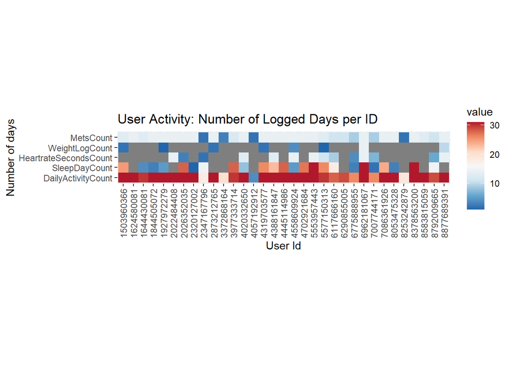

```r
## Melting data for plotting

melted_data <- reshape2::melt(records_merged, id.vars = 'Id')

## Create a heatmap

ggplot(melted_data, aes(x = as.factor(Id), y = variable, fill = value)) +
  geom_tile() +
  scale_fill_distiller(palette = "RdBu") +
  labs(title = "User Activity: Number of Logged Days per ID", x = "User Id", y = "Number of days") +
  theme(axis.text.x = element_text(angle = 90, hjust = 1, vjust = 0.5)) +
  coord_fixed()
```

## Identifying popular features

```r
## 1. Counting the number of users

num_unique_daily_activity_ids <- length(unique(daily_activity_transformed$Id))
num_unique_weight_log_ids <- length(unique(weight_transformed$Id))
num_unique_minute_METs_ids <- length(unique(minute_METs_narrow$Id))
num_unique_sleep_day_ids <- length(unique(sleep_day_transformed$Id))
num_unique_heartrate_seconds_ids <- length(unique(heartrate_seconds$Id))

## 2. Creating a data frame with the counts

records_data <- data.frame(
  Feature = c('Daily Activity', 'Weight Log', 'Minute METs', 'Sleep Day', ' Heart Rate Seconds'),
  Count = c(num_unique_daily_activity_ids, num_unique_weight_log_ids, num_unique_minute_METs_ids, num_unique_sleep_day_ids, num_unique_heartrate_seconds_ids)
)

  ## 3. Calculating percentages based on the total number of users (33)

records_data$Percentage <- (records_data$Count / 33) * 100

head(records_data)
```

```
##               Feature Count Percentage
## 1      Daily Activity    33  100.00000
## 2          Weight Log     8   24.24242
## 3         Minute METs    33  100.00000
## 4           Sleep Day    24   72.72727
## 5  Heart Rate Seconds    14   42.42424
```

### Bar Chart

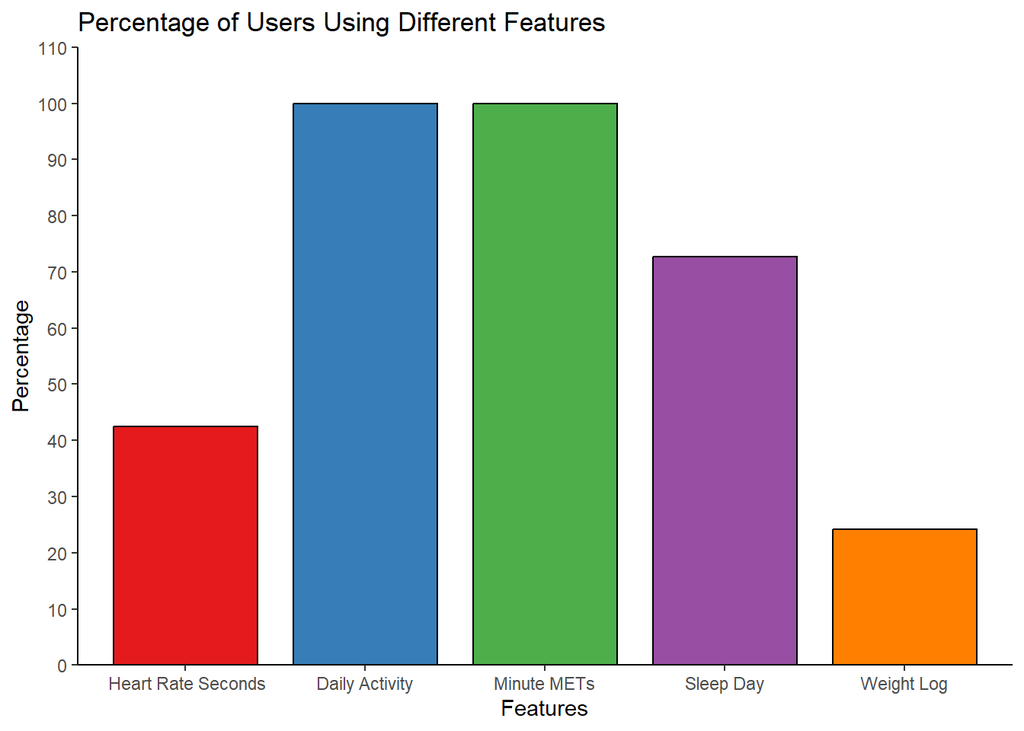

```r
ggplot(records_data, aes(x = Feature,
                        y = Percentage,
                        fill = Feature, )) +
  geom_bar(stat = "identity",
           position = "dodge",
           width = 0.8,
           color = "black") +
  scale_y_continuous(breaks = seq(0,110, 10),
                     limits = c(0,110),
                     expand = expansion(mult = 0)) +
  scale_x_discrete() +
  scale_fill_brewer(palette = "Set1") +
  labs(
    title = "Percentage of Users Using Different Features",
       x = "Features",
       y = "Percentage"
  ) +
  theme_classic() +
  theme(legend.position = "none")
```

## User Engagement

```r
## 1. Unique Ids using each feature

id_daily_activity <- unique(daily_activity_transformed$Id)
id_weight_log <- unique(weight_transformed$Id)
id_minute_METs <- unique(minute_METs_narrow$Id)
id_sleep_day <- unique(sleep_day_transformed$Id)
id_heartrate_seconds <- unique(heartrate_seconds$Id)

## 2. Find Common Ids

common_ids <- Reduce(intersect, list(id_daily_activity, id_weight_log, id_minute_METs, id_sleep_day, id_heartrate_seconds))


## 3. Find common Ids for each combination of at least 4 features

common_ids_sleep_heartrate_weight <- common_ids <- Reduce(intersect, list(id_weight_log,id_sleep_day, id_heartrate_seconds))
common_ids_sleep_heartrate_weight <- Reduce(intersect, list(id_sleep_day, id_heartrate_seconds,id_daily_activity, id_weight_log))
common_ids_sleep_heartrate <- Reduce(intersect, list(id_sleep_day, id_heartrate_seconds,id_daily_activity))
common_ids_sleep_weight <- Reduce(intersect, list(id_sleep_day, id_weight_log,id_daily_activity))
common_ids_heartrate_weight <- Reduce(intersect, list(id_heartrate_seconds, id_weight_log,id_daily_activity))

## 4. Common Ids daily activy and another feature

common_ids_sleep <- Reduce(intersect, list(id_sleep_day, id_daily_activity))
common_ids_weight <- Reduce(intersect, list(id_weight_log,id_daily_activity))
common_ids_heartrate <- Reduce(intersect, list(id_heartrate_seconds,id_daily_activity))

common_ids_all_5 <- Reduce(intersect, list(common_ids_sleep_heartrate, common_ids_sleep_weight, common_ids_heartrate_weight))
common_ids_atleast_4 <- unique(c(common_ids_sleep_heartrate, common_ids_sleep_weight, common_ids_heartrate_weight))
common_ids_atleast_3 <- unique(c(common_ids_sleep, common_ids_weight, common_ids_heartrate))

common_ids_only_2 <- setdiff(id_daily_activity,common_ids_atleast_3)
common_ids_only_3 <- setdiff(common_ids_atleast_3,common_ids_atleast_4)
common_ids_only_4 <- setdiff(common_ids_atleast_4,common_ids_all_5)

## 5. Display the combined common IDs

length(common_ids_all_5)
```

```
## [1] 3
```

```r
length(common_ids_only_4)
```

```
## [1] 13
```

```r
length(common_ids_only_3)
```

```
## [1] 11
```

```r
length(common_ids_only_2)
```

```
## [1] 6
```

```r
sum_of_lengths <- length(common_ids_all_5)+length(common_ids_only_4)+length(common_ids_only_3)+length(common_ids_only_2)

table_data <- data.frame(
  Category = c("All 5 Features", "Only 4 Features","Only 3 Features", "Only 2 Features"),
  Count = c(length(common_ids_all_5), length(common_ids_only_4),length(common_ids_only_3), length(common_ids_only_2)))

table_data$PercentageCount <- (table_data$Count/sum_of_lengths) *100
```

### Pie Chart

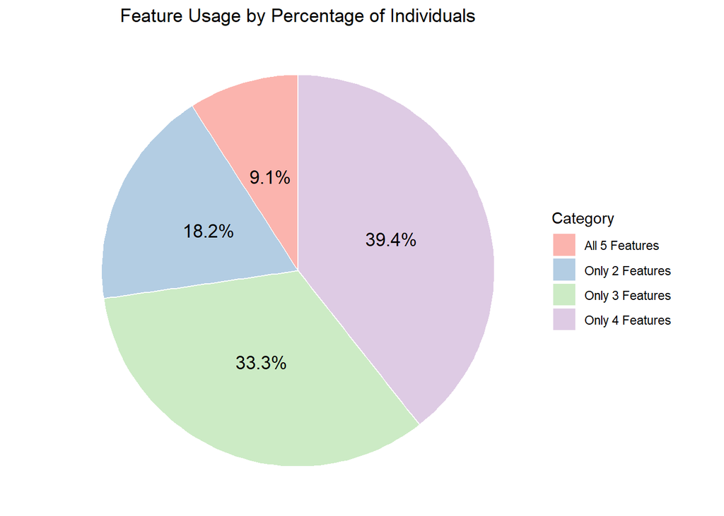

```r
ggplot(table_data, aes(x = "",
                       y = PercentageCount,
                       fill = Category)) +
  geom_bar(stat = "identity",
           width = 1,
           color = "white") +
  scale_fill_brewer(palette = "Pastel1") +
  geom_text(aes(label = sprintf("%.1f%%", PercentageCount)),
            position = position_stack(vjust = 0.5),
            size = 4.5,
            color = "black") +
  coord_polar(theta = "y") +
  labs(title = "Feature Usage by Percentage of Individuals",
       x = NULL,
       y = NULL) +
  theme_void() +
  theme(legend.position = "right",
        legend.direction = "vertical",
        plot.title = element_text(hjust = 0.5))
```

### Waffle chart for numer of functions per user

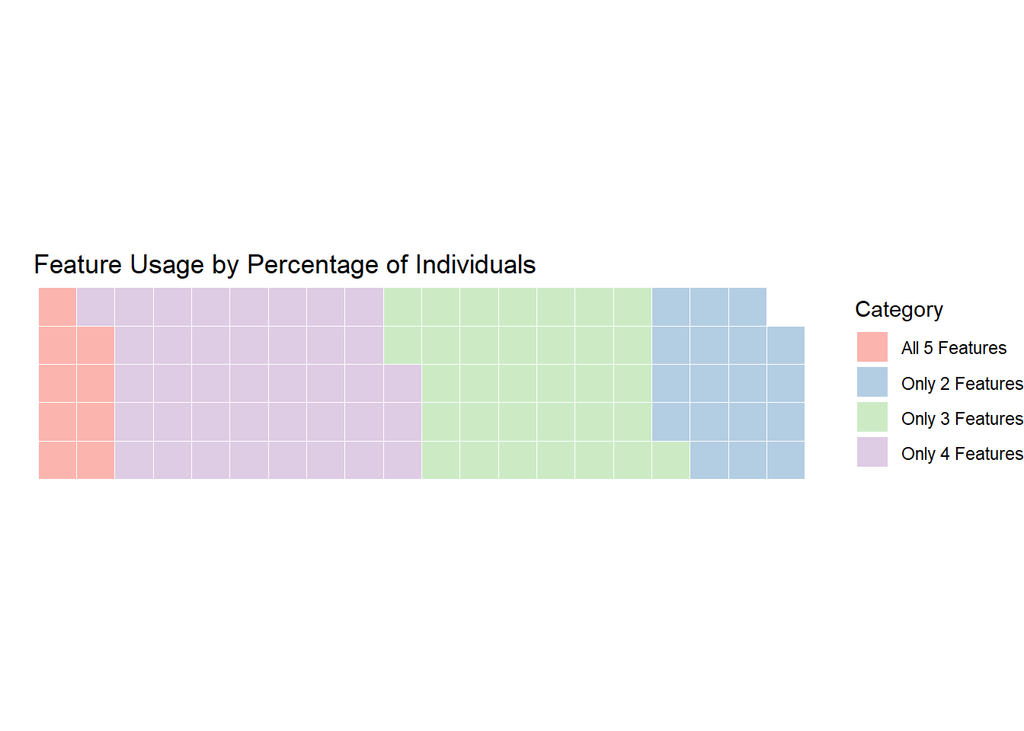

```r
ggplot(table_data, aes(fill = Category,
                       values = PercentageCount)) +
  geom_waffle(n_rows = 5,
              size = 0.33,
              colour = "white") +
  scale_fill_brewer(palette = "Pastel1") +
  coord_equal() +
  labs(title = "Feature Usage by Percentage of Individuals",
       x = NULL,
       y = NULL) +
  theme_void()+
  theme(plot.title = element_text(hjust = 0.1))
```

## Popular days of the week

```r
## Weekly analysis of intensity

daily_intensity_value <- intensity_datetime_separated %>%
  select(-ActivityHour) %>%
  group_by(intensityDate) %>%
  filter(TotalIntensity !=0) %>%
  summarize(DailyAverageIntensity = mean(TotalIntensity), .groups = "drop")

head(intensity_datetime_separated)
```

```
##           Id          ActivityHour TotalIntensity AverageIntensity
## 1 1503960366 4/12/2016 12:00:00 AM             20         0.333333
## 2 1503960366  4/12/2016 1:00:00 AM              8         0.133333
## 3 1503960366  4/12/2016 2:00:00 AM              7         0.116667
## 4 1503960366  4/12/2016 3:00:00 AM              0         0.000000
## 5 1503960366  4/12/2016 4:00:00 AM              0         0.000000
## 6 1503960366  4/12/2016 5:00:00 AM              0         0.000000
##   intensityDate intensityTime
## 1    2016-04-12      00:00:00
## 2    2016-04-12      01:00:00
## 3    2016-04-12      02:00:00
## 4    2016-04-12      03:00:00
## 5    2016-04-12      04:00:00
## 6    2016-04-12      05:00:00
```

```r
head(daily_intensity_value)
```

```
## # A tibble: 6 × 2
##   intensityDate DailyAverageIntensity
##   <date>                        <dbl>
## 1 2016-04-12                     19.6
## 2 2016-04-13                     18.6
## 3 2016-04-14                     19.3
## 4 2016-04-15                     18.9
## 5 2016-04-16                     23.2
## 6 2016-04-17                     21.3
```

```r
## Convert and add a column for the day of the week

daily_intensity_weekday <- daily_intensity_value %>%
  mutate(intensityDay = weekdays(intensityDate)) %>%
  mutate(intensityDay = factor(intensityDay,
                               levels = c("Monday",
                                          "Tuesday",
                                          "Wednesday",
                                          "Thursday",
                                          "Friday",
                                          "Saturday",
                                          "Sunday")))

## Sumarise total average intensity by day of the week

average_intensity_by_day <- daily_intensity_weekday %>%
  group_by(intensityDay) %>%
  summarise(AverageIntensityByWeekDay = mean(DailyAverageIntensity, na.rm =TRUE), .groups = "drop")

head(average_intensity_by_day)
```

```
## # A tibble: 6 × 2
##   intensityDay AverageIntensityByWeekDay
##   <fct>                            <dbl>
## 1 Monday                            21.1
## 2 Tuesday                           20.5
## 3 Wednesday                         19.5
## 4 Thursday                          19.9
## 5 Friday                            19.6
## 6 Saturday                          22.2
```

### Bar chart

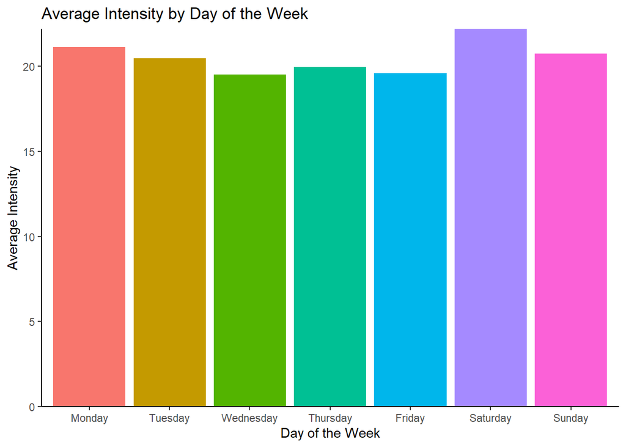

```r
ggplot(average_intensity_by_day, aes(x = intensityDay,
                                     y = AverageIntensityByWeekDay,
                                     fill = intensityDay)) +
  geom_bar(stat = "identity") +
  scale_y_continuous(expand = expansion(mult = 0)) +
  scale_x_discrete() +
  labs(title = "Average Intensity by Day of the Week",
       x = "Day of the Week",
       y = "Average Intensity") +
  theme_classic() +
  theme(legend.position = "none")
```

### Time series

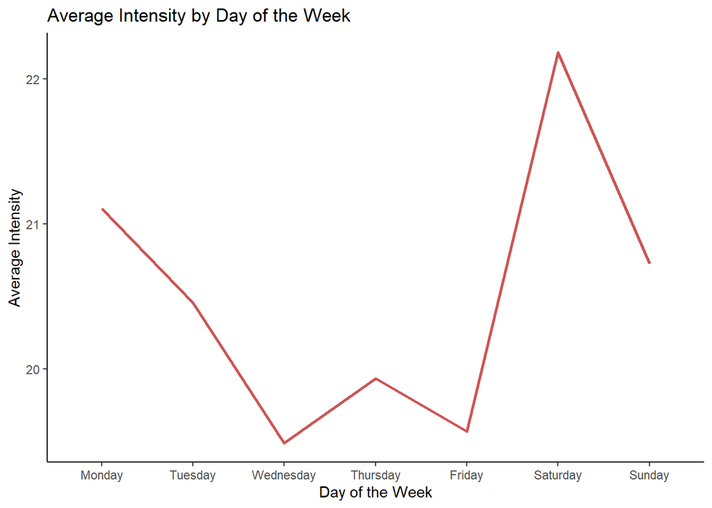

```r
ggplot(average_intensity_by_day, aes(x = intensityDay,
                                     y = AverageIntensityByWeekDay)) +
  geom_line(color = "indianred3",
            linewidth = 1,
            group = 1) +
  geom_smooth() +
  labs(title = "Average Intensity by Day of the Week",
       x = "Day of the Week",
       y = "Average Intensity") +
  theme_classic()
```

## Log patterns depending on the day of the week

```r
daily_activity_weekdays <- daily_activity_transformed %>%
  mutate(Day = weekdays(as.Date(ActivityDate,
                                format = "%d/%m/%Y"))) %>%
  mutate(Day = factor(Day, levels = c("Monday",
                                      "Tuesday",
                                      "Wednesday",
                                      "Thursday",
                                      "Friday",
                                      "Saturday",
                                      "Sunday"))) %>%
  group_by(Day) %>%
  summarize(RecordedActivityDayCount = n(), .groups = "drop") %>%
  mutate(activity_type = "Activity")

head(daily_activity_weekdays)
```

```
## # A tibble: 6 × 3
##   Day       RecordedActivityDayCount activity_type
##   <fct>                        <int> <chr>
## 1 Monday                          48 Activity
## 2 Tuesday                         88 Activity
## 3 Wednesday                       26 Activity
## 4 Thursday                        29 Activity
## 5 Friday                          56 Activity
## 6 Saturday                        53 Activity
```

```r
sleep_day_weekdays <- sleep_day_transformed %>%
  mutate(Day = weekdays(as.Date(SleepDay, format = "%d/%m/%Y"))) %>%
  mutate(Day = factor(Day, levels = c('Monday',
                                      'Tuesday',
                                      'Wednesday',
                                      'Thursday',
                                      'Friday',
                                      'Saturday',
                                      'Sunday'))) %>%
  group_by(Day) %>%
  summarize(RecordedSleepDayCount = n(), .groups = "drop") %>%
  mutate(activity_type = "Sleep")

heartrate_seconds_weekdays <- heartrate_day %>%
  mutate(Day = weekdays(as.Date(heartrateDate, format = "%d/%m/%Y"))) %>%
  mutate(Day = factor(Day, levels = c('Monday',
                                      'Tuesday',
                                      'Wednesday',
                                      'Thursday',
                                      'Friday',
                                      'Saturday',
                                      'Sunday'))) %>%
  group_by(Day) %>%
  summarize(RecordedHeartrateDayCount = n(), .groups = "drop") %>%
  mutate(activity_type = "HeartRate")

head(heartrate_seconds_weekdays)
```

```
## # A tibble: 6 × 3
##   Day       RecordedHeartrateDayCount activity_type
##   <fct>                         <int> <chr>
## 1 Monday                           44 HeartRate
## 2 Tuesday                          51 HeartRate
## 3 Wednesday                        52 HeartRate
## 4 Thursday                         52 HeartRate
## 5 Friday                           48 HeartRate
## 6 Saturday                         43 HeartRate
```

```r
weight_weekdays <- weight_transformed %>%
  mutate(Day = weekdays(as.Date(Date, format = "%d/%m/%Y"))) %>%
  mutate(Day = factor(Day, levels = c('Monday',
                                      'Tuesday',
                                      'Wednesday',
                                      'Thursday',
                                      'Friday',
                                      'Saturday',
                                      'Sunday'))) %>%
  group_by(Day) %>%
  summarize(WeightDayCount = n(), .groups = "drop") %>%
  mutate(activity_type = "Weight Log")



## Combine the data

combined_data <- bind_rows(
  mutate(daily_activity_weekdays, activity_type = "Activity"),
  mutate(sleep_day_weekdays, activity_type = "Sleep"),
  mutate(heartrate_seconds_weekdays, activity_type = "Heart Rate"),
  mutate(weight_weekdays, activity_type = "Weight")
)

long_data <- combined_data %>%
  pivot_longer(cols = c(RecordedActivityDayCount, RecordedSleepDayCount, RecordedHeartrateDayCount, WeightDayCount),
               names_to = "data_type",
               values_to = "Count") %>%
  drop_na()

head(combined_data)
```

```
## # A tibble: 6 × 6
##   Day       RecordedActivityDayCount activity_type RecordedSleepDayCount
##   <fct>                        <int> <chr>                         <int>
## 1 Monday                          48 Activity                         NA
## 2 Tuesday                         88 Activity                         NA
## 3 Wednesday                       26 Activity                         NA
## 4 Thursday                        29 Activity                         NA
## 5 Friday                          56 Activity                         NA
## 6 Saturday                        53 Activity                         NA
## # ℹ 2 more variables: RecordedHeartrateDayCount <int>, WeightDayCount <int>
```

```r
head(long_data)
```

```
## # A tibble: 6 × 4
##   Day       activity_type data_type                Count
##   <fct>     <chr>         <chr>                    <int>
## 1 Monday    Activity      RecordedActivityDayCount    48
## 2 Tuesday   Activity      RecordedActivityDayCount    88
## 3 Wednesday Activity      RecordedActivityDayCount    26
## 4 Thursday  Activity      RecordedActivityDayCount    29
## 5 Friday    Activity      RecordedActivityDayCount    56
## 6 Saturday  Activity      RecordedActivityDayCount    53
```

### Stacked bar chart for activity patterns

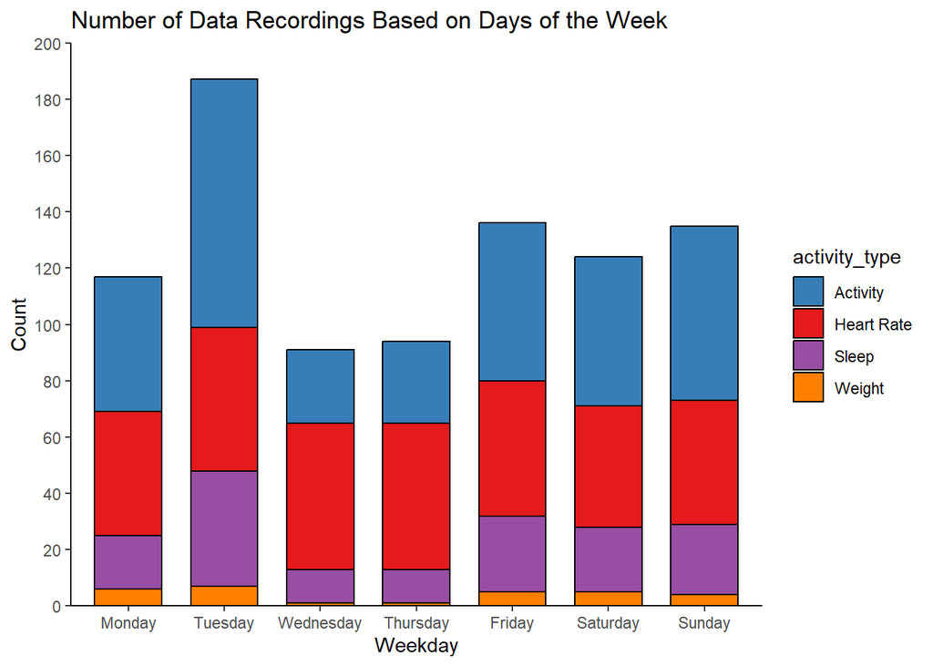

```r
ggplot(long_data, aes(x = Day, y = Count, fill = activity_type)) +
  geom_bar(stat = "identity", position = "stack", color = "black", width = 0.7) +
  labs(title = "Number of Data Recordings Based on Days of the Week",
       x = "Weekday",
       y = "Count") +
  scale_y_continuous(breaks = seq(0,200, 20),
                     limits = c(0,200),
                     expand = expansion(mult = 0)) +
  scale_x_discrete() +
  scale_fill_manual(values = c("#377EB8", "#E41A1C", "#984EA3", "#FF7F00")) +
  theme_classic()
```

## Activity metric by day of the week

```r
daily_activity_weekdays_average <- daily_activity_updated %>%
  mutate(activityDay = weekdays(as.Date(ActivityDate))) %>%
  mutate(activityDay = factor(activityDay, levels = c("Monday",
                                                      "Tuesday",
                                                      "Wednesday",
                                                      "Thursday",
                                                      "Friday",
                                                      "Saturday",
                                                      "Sunday"))) %>%
  group_by(activityDay) %>%
  filter_all(any_vars(. != 0)) %>%
  summarize(
    Average_Steps = mean(TotalSteps),
    Average_Calories = mean(Calories),
    Average_Sedentary_Minutes = mean(SedentaryMinutes),
    Average_Active_Minutes = mean(TotalActiveMinutes),
    .groups = "drop"
  ) %>%
  drop_na()

head(daily_activity_weekdays_average)
```

```
## # A tibble: 6 × 5
##   activityDay Average_Steps Average_Calories Average_Sedentary_Minutes
##   <fct>               <dbl>            <dbl>                     <dbl>
## 1 Monday              8267.            2415.                      988.
## 2 Tuesday             7216.            1947.                      760.
## 3 Wednesday           7842.            2362.                      961.
## 4 Thursday            8272.            2348.                      926.
## 5 Friday              9738.            2479.                      986.
## 6 Saturday            8275.            2403.                      874.
## # ℹ 1 more variable: Average_Active_Minutes <dbl>
```

```r
daily_activity_weekdays_long <- daily_activity_weekdays_average %>%
  pivot_longer(cols = c(
    Average_Steps,
    Average_Calories,
    Average_Sedentary_Minutes,
    Average_Active_Minutes),
    names_to = "Metric",
    values_to = "Value")

head(daily_activity_weekdays_long)
```

```
## # A tibble: 6 × 3
##   activityDay Metric                    Value
##   <fct>       <chr>                     <dbl>
## 1 Monday      Average_Steps             8267.
## 2 Monday      Average_Calories          2415.
## 3 Monday      Average_Sedentary_Minutes  988.
## 4 Monday      Average_Active_Minutes     252.
## 5 Tuesday     Average_Steps             7216.
## 6 Tuesday     Average_Calories          1947.
```

```r
##Prepare data for charting

### Separate data for bar charts and line charts

bar_chart_data <- daily_activity_weekdays_long %>%
  filter(Metric != "Average_Activity_Minutes")

line_chart_data <- daily_activity_weekdays_long %>%
  filter(Metric == "Average_Active_Minutes")

head(bar_chart_data)
```

```
## # A tibble: 6 × 3
##   activityDay Metric                    Value
##   <fct>       <chr>                     <dbl>
## 1 Monday      Average_Steps             8267.
## 2 Monday      Average_Calories          2415.
## 3 Monday      Average_Sedentary_Minutes  988.
## 4 Monday      Average_Active_Minutes     252.
## 5 Tuesday     Average_Steps             7216.
## 6 Tuesday     Average_Calories          1947.
```

```r
head(line_chart_data)
```

```
## # A tibble: 6 × 3
##   activityDay Metric                 Value
##   <fct>       <chr>                  <dbl>
## 1 Monday      Average_Active_Minutes  252.
## 2 Tuesday     Average_Active_Minutes  212.
## 3 Wednesday   Average_Active_Minutes  239.
## 4 Thursday    Average_Active_Minutes  235.
## 5 Friday      Average_Active_Minutes  273
## 6 Saturday    Average_Active_Minutes  257.
```

### Combination Chart

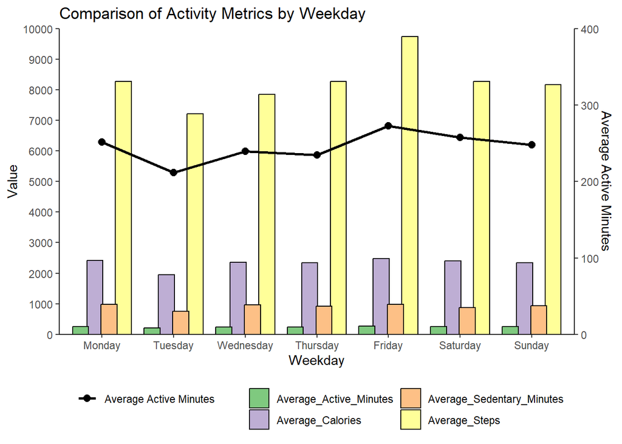

```r
  ggplot() +
  geom_bar(data = bar_chart_data, aes(x = activityDay,
                                      y = Value,
                                      fill = Metric),
           stat = "identity",
           position = position_dodge(width = 0.8),
           color = "black",
           size = 0.5) +
  geom_line(data = line_chart_data, aes(x = activityDay,
                                        y = Value * 25,
                                        color = "Average Active Minutes"),
            size = 1.0,
            group = 1) +
  geom_point(data = line_chart_data, aes(x = activityDay,
                                         y = Value * 25,
                                         colour = "Average Active Minutes"),
             size = 2.5) +
  labs(title = "Comparison of Activity Metrics by Weekday",
       x = "Weekday",
       y = "Value") +
  scale_fill_brewer(palette = "Accent") +
  scale_color_manual(values = c("Average Active Minutes" = "black")) +
  theme_classic() +
  theme(legend.title = element_blank(),
        legend.position = "bottom") +
  guides(fill = guide_legend(ncol = 2)) +
  scale_y_continuous(expand = expansion(mult = 0),
                     limits = c(0, 10000),
                     breaks = seq(0, 10000, 1000),
                     sec.axis = sec_axis(~./25,
                                         name = "Average Active Minutes"))
```

## Intense Activity Peak Times

```r
## Time of day analysis

intensity_value_by_time <- intensity_datetime_separated %>%
  separate(intensityTime, c("Hour", "Minute", "Second")) %>%
  mutate(Hour = as.numeric(Hour)) %>%
  group_by(Hour) %>%
  summarise(TotalAverageIntensity = sum(AverageIntensity,
                                        na.rm = TRUE),
            .groups = "drop")

head(intensity_value_by_time)
```

```
## # A tibble: 6 × 2
##    Hour TotalAverageIntensity
##   <dbl>                 <dbl>
## 1     0                 33.2
## 2     1                 22.1
## 3     2                 16.2
## 4     3                  6.90
## 5     4                  9.83
## 6     5                 76.9
```

```r
max_intensity_value_by_time <- intensity_value_by_time %>%
  mutate(ToHighLight = ifelse(TotalAverageIntensity == max(TotalAverageIntensity), "yes", "no"))

head(max_intensity_value_by_time)
```

```
## # A tibble: 6 × 3
##    Hour TotalAverageIntensity ToHighLight
##   <dbl>                 <dbl> <chr>
## 1     0                 33.2  no
## 2     1                 22.1  no
## 3     2                 16.2  no
## 4     3                  6.90 no
## 5     4                  9.83 no
## 6     5                 76.9  no
```

### Histogram representation of intensity analysis

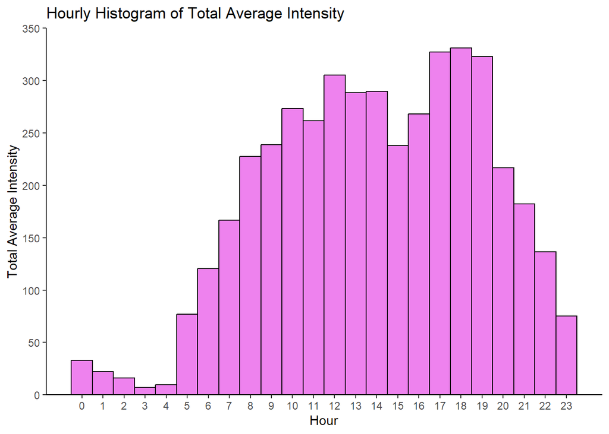

```r
ggplot(intensity_value_by_time, aes(x = Hour,
                                    y = TotalAverageIntensity)) +
  geom_bar(stat = "identity",
           fill = "violet",
           color = "black",
           width = 1) +
  labs(title = "Hourly Histogram of Total Average Intensity",
       x = "Hour",
       y = "Total Average Intensity") +
  scale_x_continuous(breaks = seq(0, 23, by = 1)) +
  scale_y_continuous(expand = expansion(mult = 0),
                     limits = c(0, 350),
                     breaks = seq(0, 350, 50)) +
  theme_classic()
```

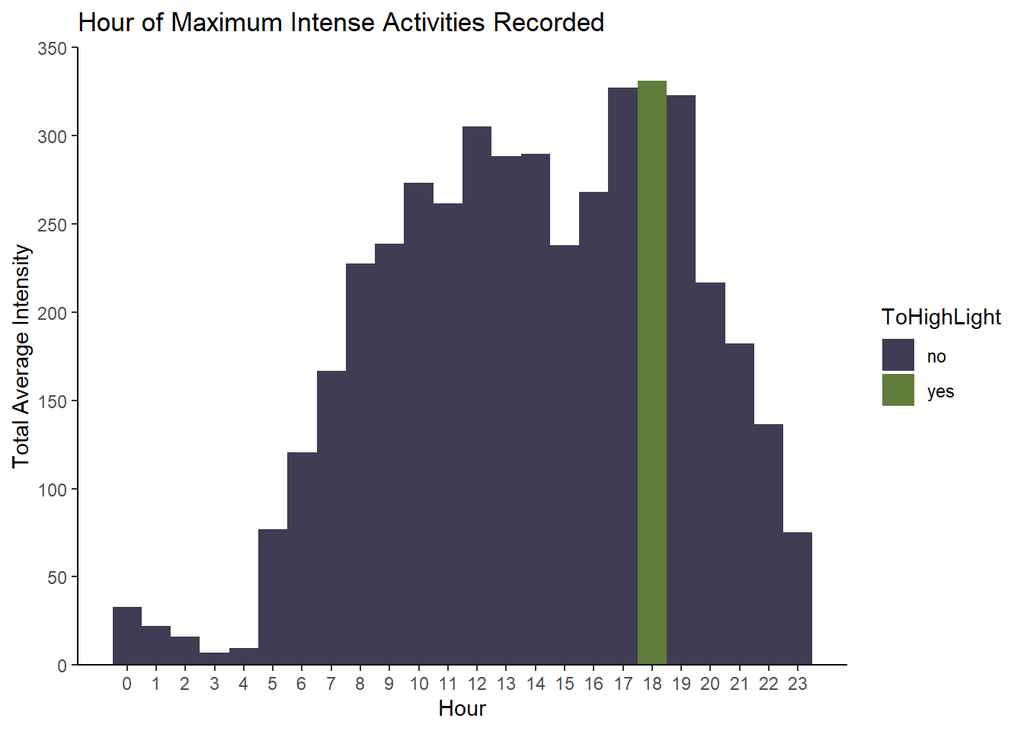

```r
ggplot(max_intensity_value_by_time, aes(x = Hour,
                                    y = TotalAverageIntensity,
                                    fill = ToHighLight)) +
  geom_bar(stat = "identity",
           width = 1) +
  scale_fill_manual(values = c("yes" = "#607d3b", "no" = "#3E3D53")) +
  labs(title = "Hour of Maximum Intense Activities Recorded",
       x = "Hour",
       y = "Total Average Intensity") +
  scale_x_continuous(breaks = seq(0, 23, by = 1)) +
  scale_y_continuous(expand = expansion(mult = 0),
                     limits = c(0, 350),
                     breaks = seq(0, 350, 50)) +
  theme_classic()
```

## Correlations

### Correlation between daily activities and BMI

```r
## Classify BMI

average_BMI_individual <- weight_transformed %>%
  group_by(Id) %>%
  summarise(AverageBMI = mean(BMI),
            .groups = "drop") %>%
  mutate(type = case_when(
    AverageBMI <18 ~ "underweight",
    between(AverageBMI, 18.5, 24.9) ~ "healthyweight",
    between(AverageBMI, 25.0, 29.9) ~ "overweight",
    AverageBMI >= 30.0 ~ "obese",
    TRUE ~ NA_character_
  ))

head(average_BMI_individual)
```

```
## # A tibble: 6 × 3
##           Id AverageBMI type
##        <dbl>      <dbl> <chr>
## 1 1503960366       22.6 healthyweight
## 2 1927972279       47.5 obese
## 3 2873212765       21.6 healthyweight
## 4 4319703577       27.4 overweight
## 5 4558609924       27.2 overweight
## 6 5577150313       28   overweight
```

```r
## Merge activities and BMI by Id value

activity_weight_merged <- average_BMI_individual %>%
  left_join(daily_activity_summary_average, by = "Id") %>%
  drop_na()

head(activity_weight_merged)
```

```
## # A tibble: 6 × 10
##           Id AverageBMI type          average_distance average_active_distance
##        <dbl>      <dbl> <chr>                    <dbl>                   <dbl>
## 1 1503960366       22.6 healthyweight             8.07                    8.07
## 2 1927972279       47.5 obese                     1.16                    1.16
## 3 2873212765       21.6 healthyweight             5.10                    5.10
## 4 4319703577       27.4 overweight                4.88                    4.70
## 5 4558609924       27.2 overweight                5.08                    5.08
## 6 5577150313       28   overweight                6.66                    6.64
## # ℹ 5 more variables: average_sedentary_distance <dbl>,
## #   average_active_minutes <dbl>, average_sedentary_minutes <dbl>,
## #   average_calories <dbl>, average_steps <dbl>
```

```r
## Correlations

correlations_activity_weight <- cor(activity_weight_merged[,
                                                           c("AverageBMI",
                                                             "average_active_distance",
                                                             "average_sedentary_distance",
                                                             "average_active_minutes",
                                                             "average_sedentary_minutes",
                                                             "average_calories",
                                                             "average_steps")])

head(correlations_activity_weight)
```

```
##                             AverageBMI average_active_distance
## AverageBMI                  1.00000000              -0.5999947
## average_active_distance    -0.59999467               1.0000000
## average_sedentary_distance -0.42249691               0.4304531
## average_active_minutes     -0.96028217               0.6357302
## average_sedentary_minutes   0.47086737              -0.1356278
## average_calories            0.09338174               0.5249082
##                            average_sedentary_distance average_active_minutes
## AverageBMI                               -0.422496913            -0.96028217
## average_active_distance                   0.430453122             0.63573021
## average_sedentary_distance                1.000000000             0.40330404
## average_active_minutes                    0.403304042             1.00000000
## average_sedentary_minutes                -0.008754585            -0.33653226
## average_calories                          0.020610076             0.05982151
##                            average_sedentary_minutes average_calories
## AverageBMI                               0.470867372       0.09338174
## average_active_distance                 -0.135627787       0.52490816
## average_sedentary_distance              -0.008754585       0.02061008
## average_active_minutes                  -0.336532261       0.05982151
## average_sedentary_minutes                1.000000000       0.01856626
## average_calories                         0.018566265       1.00000000
##                            average_steps
## AverageBMI                    -0.7094996
## average_active_distance        0.9786371
## average_sedentary_distance     0.4043569
## average_active_minutes         0.7094059
## average_sedentary_minutes     -0.2438992
## average_calories               0.3770871
```

##### Correlation plot

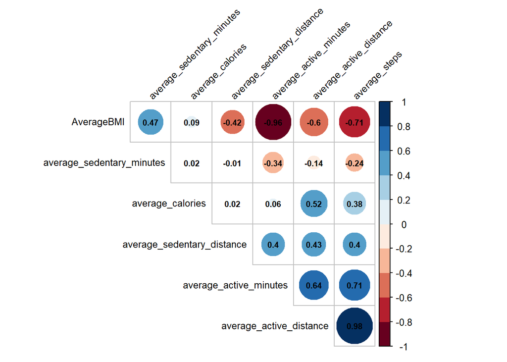

```r
corrplot(correlations_activity_weight,
         method = "circle",
         type = "upper",
         order = "hclust",
         addrect = 2,
         col = COL2("RdBu", 10),
         cl.ratio = 0.2,
         tl.col ="black",
         tl.cex = 0.8,
         tl.srt = 45,
         addCoef.col = "black",
         diag = FALSE,
         number.cex = 0.7
)
```

### Correlation at the minute level

```r
##  Convert Date and Time columns into the appropriate formats

minute_calories_formatted_1 <- minute_calories_formatted %>%
  mutate(DateTime = as.POSIXct(paste(MinuteCaloriesDate, MinuteCaloriesTime),
                               format = "%Y-%m-%d %H:%M:%S"))

head(minute_calories_formatted_1)
```

```
##           Id Calories MinuteCaloriesDate MinuteCaloriesTime            DateTime
## 1 1503960366   0.7865         2016-04-12           00:00:00 2016-04-12 00:00:00
## 2 1503960366   0.7865         2016-04-12           00:01:00 2016-04-12 00:01:00
## 3 1503960366   0.7865         2016-04-12           00:02:00 2016-04-12 00:02:00
## 4 1503960366   0.7865         2016-04-12           00:03:00 2016-04-12 00:03:00
## 5 1503960366   0.7865         2016-04-12           00:04:00 2016-04-12 00:04:00
## 6 1503960366   0.9438         2016-04-12           00:05:00 2016-04-12 00:05:00
```

```r
steps_datetime_minute_1 <- steps_datetime_minute %>%
  mutate(DateTime_steps = as.POSIXct(paste(stepsDate, stepsTime), format = "%Y-%m-%d %H:%M:%S"))

MET_datetime_minute_1 <- MET_datetime_minute %>%
  mutate(DateTime_MET = as.POSIXct(paste(METDate, METTime), format = "%Y-%m-%d %H:%M:%S"))

minute_intensities_formatted_1 <- minute_intensities_formatted %>%
  mutate(DateTime_intensity = as.POSIXct(paste(MinuteIntensitiesDate, MinuteIntensitiesTime), format = "%Y-%m-%d %H:%M:%S"))

## Merge data

merged_data <- left_join(minute_calories_formatted_1,
                         steps_datetime_minute_1,
                         by = c("Id", "DateTime" = "DateTime_steps")) %>%
  left_join(., MET_datetime_minute_1,
            by = c("Id", "DateTime" = "DateTime_MET")) %>%
  left_join(., minute_intensities_formatted_1,
            by = c("Id", "DateTime" = "DateTime_intensity")) %>%
  select(Id, Calories, stepsDate, stepsTime, METs, Intensity, Steps, DateTime)

head(merged_data)
```

```
##           Id Calories  stepsDate stepsTime METs Intensity Steps
## 1 1503960366   0.7865 2016-04-12  00:00:00   10         0     0
## 2 1503960366   0.7865 2016-04-12  00:01:00   10         0     0
## 3 1503960366   0.7865 2016-04-12  00:02:00   10         0     0
## 4 1503960366   0.7865 2016-04-12  00:03:00   10         0     0
## 5 1503960366   0.7865 2016-04-12  00:04:00   10         0     0
## 6 1503960366   0.9438 2016-04-12  00:05:00   12         0     0
##              DateTime
## 1 2016-04-12 00:00:00
## 2 2016-04-12 00:01:00
## 3 2016-04-12 00:02:00
## 4 2016-04-12 00:03:00
## 5 2016-04-12 00:04:00
## 6 2016-04-12 00:05:00
```

```r
## Correlation Analysis

correlations_merged <- cor(merged_data[, c("Calories", "METs", "Steps", "Intensity")])

head(correlations_merged)
```

```
##            Calories      METs     Steps Intensity
## Calories  1.0000000 0.9559606 0.8310611 0.8903412
## METs      0.9559606 1.0000000 0.8870067 0.9391703
## Steps     0.8310611 0.8870067 1.0000000 0.8093971
## Intensity 0.8903412 0.9391703 0.8093971 1.0000000
```

##### Correlation plot

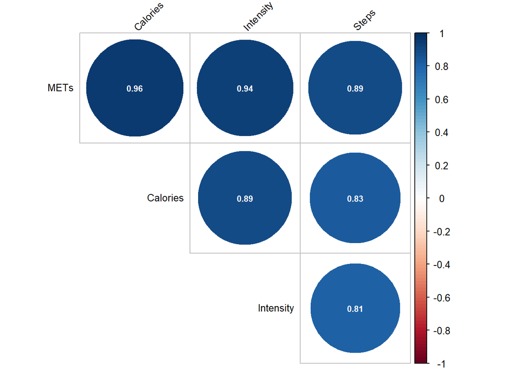

```r
corrplot(correlations_merged,
         method ="circle",
         type = "upper",
         order = "FPC",
         addrect = 2,
         col = COL2("RdBu", 100),
         cl.ratio = 0.2,
         tl.col ="black",
         tl.cex = 0.8,
         tl.srt = 45,
         addCoef.col = "white",
         diag = FALSE,
         number.cex = 0.7)
```

## Sleep Analysis

#### Most Prevalent Sleep Times

```r
### Formating minute_sleep

minute_sleep_formatted1 <- minute_sleep_formatted %>%
  mutate(MinuteSleepTime = as.POSIXct(MinuteSleepTime,
                                      format = "%H:%M:%S"),
         Hour = as.numeric(format(MinuteSleepTime, "%H")))

head(minute_sleep_formatted1)
```

```
##           Id value       logId MinuteSleepDate     MinuteSleepTime Hour
## 1 1503960366     3 11380564589      2016-04-12 2024-01-04 02:47:30    2
## 2 1503960366     2 11380564589      2016-04-12 2024-01-04 02:48:30    2
## 3 1503960366     1 11380564589      2016-04-12 2024-01-04 02:49:30    2
## 4 1503960366     1 11380564589      2016-04-12 2024-01-04 02:50:30    2
## 5 1503960366     1 11380564589      2016-04-12 2024-01-04 02:51:30    2
## 6 1503960366     1 11380564589      2016-04-12 2024-01-04 02:52:30    2
```

##### Histogram for representation

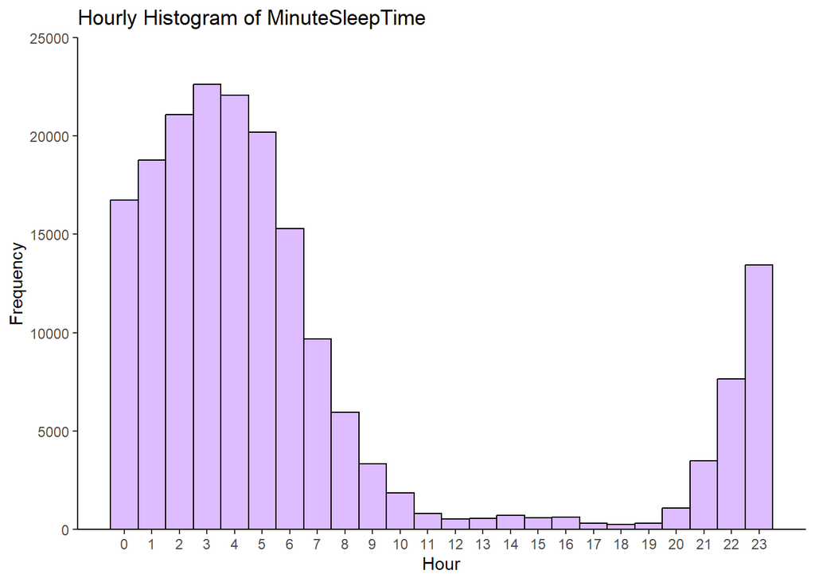

```r
ggplot(data = minute_sleep_formatted1, aes(x = Hour)) +
  geom_histogram(binwidth = 1,
                 fill = "#CF9FFF",
                 color= "black",
                 alpha = 0.7) +
  labs(title = "Hourly Histogram of MinuteSleepTime",
       x = "Hour",
       y = "Frequency") +
  scale_y_continuous(expand = expansion(mult = 0),
                     limits = c(0, 25000),
                     breaks = seq(0, 30000, 5000)) +
  scale_x_continuous(breaks = seq(0, 23, by = 1)) +
  theme_classic()
```

#### Average Sleep duration by weekday

```r
sleep_day_weekdays_updated <- sleep_day_transformed %>%
  mutate(sleepDay = weekdays(as.Date(SleepDay)),
         sleepTime = format(SleepDay, format = "%H:%M:%S")) %>%
  mutate(sleepDay = factor(sleepDay,
                           levels = c("Monday",
                                      "Tuesday",
                                      "Wednesday",
                                      "Thursday",
                                      "Friday",
                                      "Saturday",
                                      "Sunday"))) %>%
  group_by(sleepDay) %>%
  summarize(TotalSleepDuration_hours = sum(TotalMinutesAsleep,na.rm = TRUE)/60,
            MeanSleepDuration_hours = mean(TotalMinutesAsleep)/60,
            .groups = "drop") %>%
  drop_na()

head(sleep_day_weekdays_updated)
```

```
## # A tibble: 6 × 3
##   sleepDay  TotalSleepDuration_hours MeanSleepDuration_hours
##   <fct>                        <dbl>                   <dbl>
## 1 Monday                       178.                     7.12
## 2 Tuesday                      135.                     7.12
## 3 Wednesday                    174                      6.96
## 4 Thursday                     195.                     6.96
## 5 Friday                        72.3                    6.03
## 6 Saturday                     103.                     7.38
```

##### Line Chart for sleep analysis

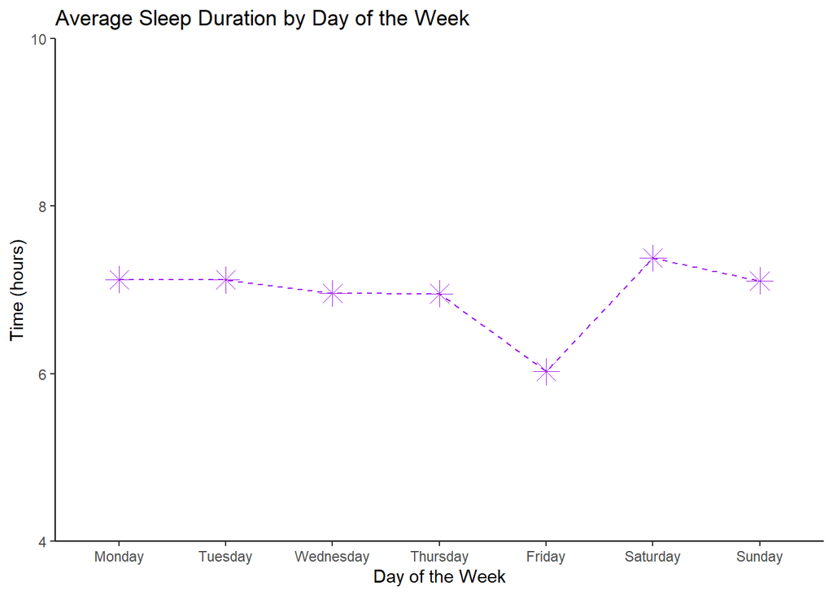

```r
ggplot(data = sleep_day_weekdays_updated, aes(x = sleepDay,
                                              y = MeanSleepDuration_hours,
                                              fill = sleepDay,
                                              group = 1,)) +
  geom_line(linetype = "dashed",
            color = "purple") +
  geom_point(color = "purple",
             size = 5,
             shape = 8) +
  labs(title = "Average Sleep Duration by Day of the Week",
       x = "Day of the Week",
       y = "Time (hours)") +
  theme_classic() +
  theme(legend.position = "none") +
   scale_y_continuous(expand = expansion(mult = 0),
                     limits = c(4, 10),
                     breaks = seq(4, 10, 2))
```

#### Average Sleep Duration by User

```r
average_sleep_duration <- sleep_day_transformed %>%
  group_by(Id) %>%
  summarise(MeanSleepDuration = mean(TotalMinutesAsleep),
             .groups = "drop") %>%
  drop_na()

head(average_sleep_duration)
```

```
## # A tibble: 6 × 2
##           Id MeanSleepDuration
##        <dbl>             <dbl>
## 1 1503960366              360.
## 2 1644430081              294
## 3 1844505072              652
## 4 1927972279              417
## 5 2026352035              506.
## 6 2320127002               61
```

##### Bar graph for representation

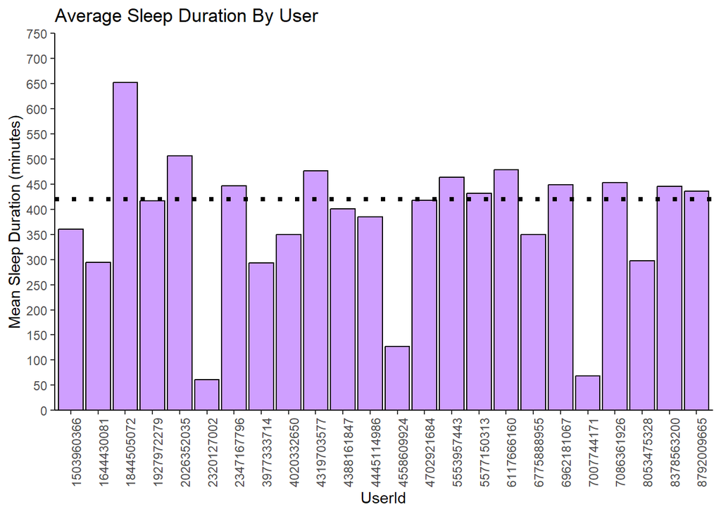

```r
ggplot(average_sleep_duration, aes(x = factor(Id),
                                   y = MeanSleepDuration)) +
  geom_bar(stat = "identity",
           fill = "#CF9FFF",
           color = "black") +
  geom_hline(yintercept = 420,
             linetype = "dotted",
             linewidth = 1.5,
             color = "black") +
  labs(title = "Average Sleep Duration By User",
       x= "UserId",
       y = "Mean Sleep Duration (minutes)") +
  scale_y_continuous(expand = expansion(mult = 0),
                     limits = c(0, 750),
                     breaks = seq(0, 750, 50)) +
  theme_classic() +
  theme(axis.text.x = element_text(angle = 90, vjust =1))
```

#### Percentage of users that get adequate amount of sleep

```r
Average_sleep_duration_categories <- average_sleep_duration %>%
  mutate(SleepCategory = case_when(
    MeanSleepDuration >= 420 ~ "Adequate Sleep",
    TRUE ~ "Not Adequate Sleep"
  ))

Adequate_Sleep_Percentage <- Average_sleep_duration_categories %>%
  select("SleepCategory", "MeanSleepDuration") %>%
  group_by(SleepCategory) %>%
  summarise(Percentage = n() / nrow(Average_sleep_duration_categories) * 100)


head(Adequate_Sleep_Percentage)
```

```
## # A tibble: 2 × 2
##   SleepCategory      Percentage
##   <chr>                   <dbl>
## 1 Adequate Sleep           45.8
## 2 Not Adequate Sleep       54.2
```

##### Pie chart for representation

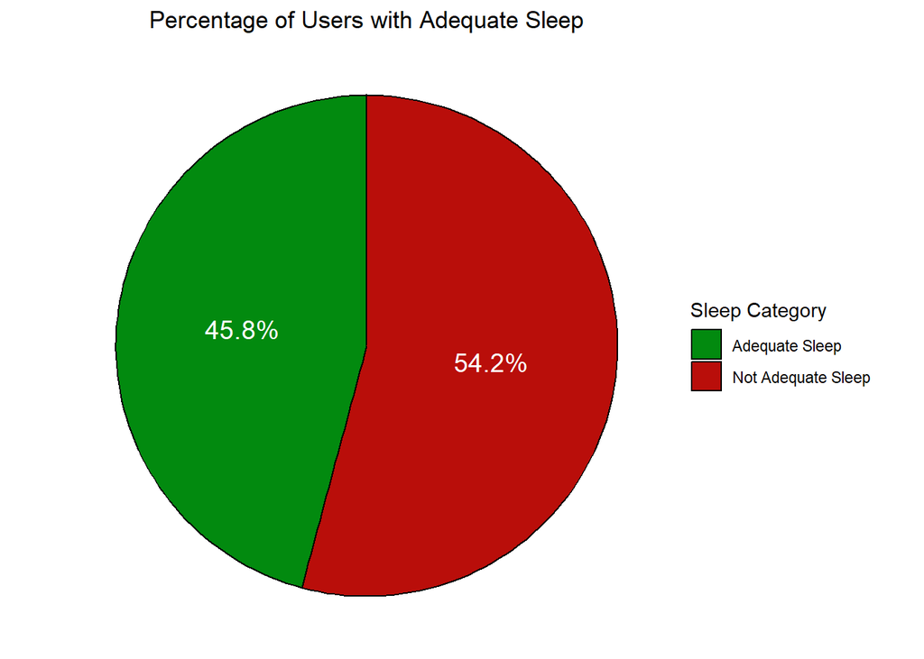

```r
ggplot(Adequate_Sleep_Percentage, aes(x = "",
                                      y = Percentage,
                                      fill = SleepCategory)) +
  geom_bar(stat = "identity",
           width = 1,
           color = "black") +
  coord_polar("y") +
  scale_fill_manual(values = c("#028A0F", "#B90E0A")) +
  geom_text(aes(label = sprintf("%.1f%%",
                               Percentage)),
            position = position_stack(vjust = 0.5),
                                      size = 5,
            color = "white") +
  labs(title ="Percentage of Users with Adequate Sleep",
                   fill = "Sleep Category" ) +
  theme_void() +
  theme(plot.title = element_text(hjust = 0.5))
```

#### Sleep values

```r
## Calculate counts


number_of_each_sleep_value <- minute_sleep_values %>%
  group_by(SleepValue) %>%
  summarise(minute_sleep_value_counts = n(),
            .groups = "drop")

head(number_of_each_sleep_value)
```

```
## # A tibble: 3 × 2
##   SleepValue    minute_sleep_value_counts
##   <chr>                             <int>
## 1 value 1 sleep                    171960
## 2 value 2 sleep                     14002
## 3 value 3 sleep                      2016
```

```r
## Calculate percentage

total_counts <- sum(number_of_each_sleep_value$minute_sleep_value_counts)

number_of_each_sleep_value$Percentage <- (number_of_each_sleep_value$minute_sleep_value_counts / total_counts) * 100

head(total_counts)
```

```
## [1] 187978
```

```r
head(number_of_each_sleep_value)
```

```
## # A tibble: 3 × 3
##   SleepValue    minute_sleep_value_counts Percentage
##   <chr>                             <int>      <dbl>
## 1 value 1 sleep                    171960      91.5
## 2 value 2 sleep                     14002       7.45
## 3 value 3 sleep                      2016       1.07
```

```r
label_position <- max(number_of_each_sleep_value$Percentage * 1000) + 10
```

##### Combination chart for visualization

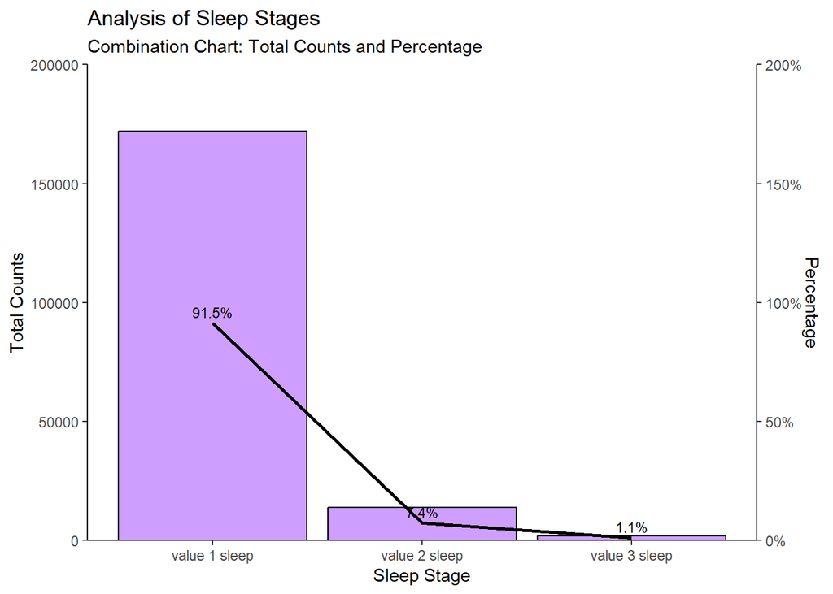

```r
ggplot(number_of_each_sleep_value, aes(x = SleepValue)) +
  geom_bar(aes(y = minute_sleep_value_counts,
               fill = "Total Counts"),
           stat = "identity",
           position = "dodge",
           color = "black") +
  geom_line(aes(y = Percentage * 1000,
                group = 1,
                color = "Percentage"),
            stat = "identity",
            size = 1) +
  geom_text(aes(y = Percentage * 1000,
                label = sprintf("%.1f%%", Percentage)),
            vjust = -0.5,
            hjust = 0.5,
            size = 3,
            color = "black")+  # Add percentage labels
  scale_y_continuous(expand = expansion(mult = 0),
                     limits = c(0, 200000),
                     breaks = seq(0, 200000, 50000),
                     sec.axis = sec_axis(trans = ~./10000,
                                         name = "Percentage",
                                         breaks = pretty_breaks(n = 5),
                                         labels = percent_format(scale = 10))) +

  scale_fill_manual(values = "#cf9fff") +
  scale_color_manual(values = "black") +
  labs(title = "Analysis of Sleep Stages",
       subtitle = "Combination Chart: Total Counts and Percentage",
       x = "Sleep Stage",
       y = "Total Counts") +
  theme_classic() +
  theme(legend.position = "none")
```

## Relationship between METs and heartrate

```r
## Merge data calibrated in minutes

merged_METs_heartrate <- MET_datetime_minute %>%
  inner_join(heartrate_minute, by = c("Id",
                                      "METDate" = "heartrateDate",
                                      "METTime" = "minute_floor"))

## Compute correlation coefficients

correlation_METs_heartrate <- cor(merged_METs_heartrate$METs,
                                  merged_METs_heartrate$mean_heartrate)
paste("Pearson Correlation Coefficient: ", round(correlation_METs_heartrate, 4))
```

```
## [1] "Pearson Correlation Coefficient:  0.7594"
```

#### Scatter Plots for visualization

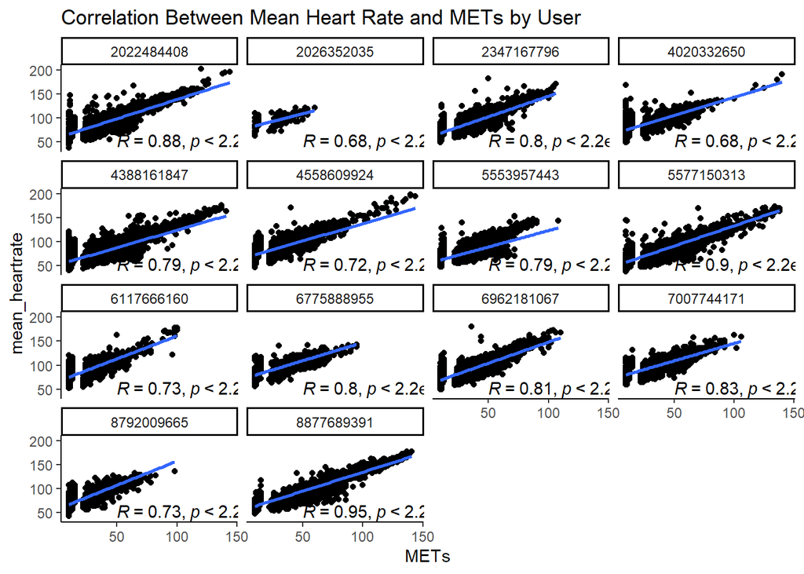

```r
ggplot(merged_METs_heartrate, aes(x = METs,
                                  y = mean_heartrate)) +
  geom_point() +
  geom_smooth(method = "lm",
              formula = y ~ x) +  ### <- Adds regression line
  stat_cor(method = "pearson",
           label.x = 50,
           label.y = 50) +
  facet_wrap(~Id) +
  labs(title = "Correlation Between Mean Heart Rate and METs by User") +
  theme_classic()
```

## Relationship between steps and heartrate

```r
merged_steps_heartrate <- steps_datetime_minute %>%
  inner_join(heartrate_minute, by = c("Id",
                                      "stepsDate" = "heartrateDate",
                                      "stepsTime" = "minute_floor")) %>%
  group_by(Id)

head(merged_steps_heartrate)
```

```
## # A tibble: 6 × 5
## # Groups:   Id [1]
##           Id Steps stepsDate  stepsTime mean_heartrate
##        <dbl> <int> <date>     <chr>              <dbl>
## 1 2022484408    17 2016-04-12 07:21:00              97
## 2 2022484408     0 2016-04-12 07:23:00              60
## 3 2022484408     0 2016-04-12 07:24:00              58
## 4 2022484408     7 2016-04-12 07:26:00              53
## 5 2022484408     0 2016-04-12 07:27:00              53
## 6 2022484408    13 2016-04-12 07:28:00              60
```

```r
correlation_steps_heartrate <- cor(merged_steps_heartrate$Steps,
                                   merged_steps_heartrate$mean_heartrate)

paste("Pearson Correlation Coefficient: ",
      round(correlation_steps_heartrate, 4))
```

```
## [1] "Pearson Correlation Coefficient:  0.6016"
```

#### Scatter plot for visualization

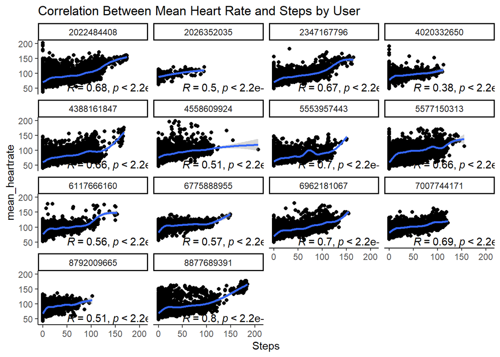

```r
ggplot(merged_steps_heartrate, aes(x = Steps,
                                   y = mean_heartrate)) +
  geom_point() +
  geom_smooth() + ## <- Adds regression line
  stat_cor(method = "pearson",
           label.x = 50,
           label.y = 50) +
  facet_wrap(~Id) +
  labs(title = "Correlation Between Mean Heart Rate and Steps by User") +
  theme_classic()
```

## Relationship between intensity level and Heart Rate

```r
merged_heartrate_intensity <- left_join(heartrate_minute,
                                        minute_intensity_level,
                                        by = c("Id",
                                               "heartrateDate" = "minuteIntensityDate",
                                               "minute_floor" = "minuteIntensityTime")) %>%
  drop_na()

head(merged_heartrate_intensity)
```

```
## # A tibble: 6 × 6
##           Id heartrateDate minute_floor mean_heartrate Intensity IntensityLevel
##        <dbl> <date>        <chr>                 <dbl>     <int> <chr>
## 1 2022484408 2016-04-12    07:21:00                 97         1 lightly active
## 2 2022484408 2016-04-12    07:23:00                 60         0 resting
## 3 2022484408 2016-04-12    07:24:00                 58         0 resting
## 4 2022484408 2016-04-12    07:26:00                 53         1 lightly active
## 5 2022484408 2016-04-12    07:27:00                 53         0 resting
## 6 2022484408 2016-04-12    07:28:00                 60         1 lightly active
```

#### Boxplot for visualization

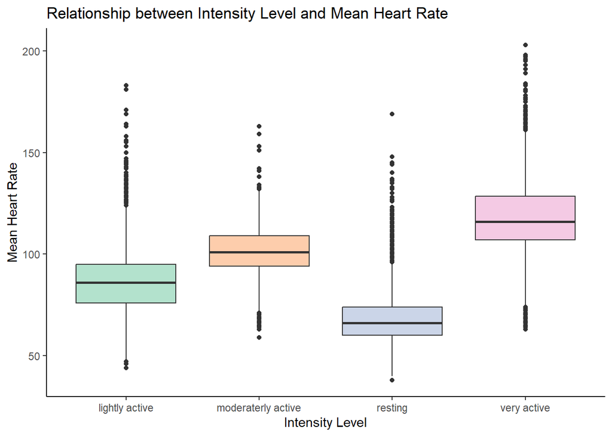

```r
## general

ggplot(merged_heartrate_intensity, aes(x = IntensityLevel,
                                       y = mean_heartrate,
                                       fill = IntensityLevel)) +
  geom_boxplot() +
  scale_fill_brewer(palette = "Pastel2") +
  labs(title = "Relationship between Intensity Level and Mean Heart Rate",
       x = "Intensity Level",
       y = "Mean Heart Rate") +
  theme_classic() +
  theme(legend.position = "none")
```

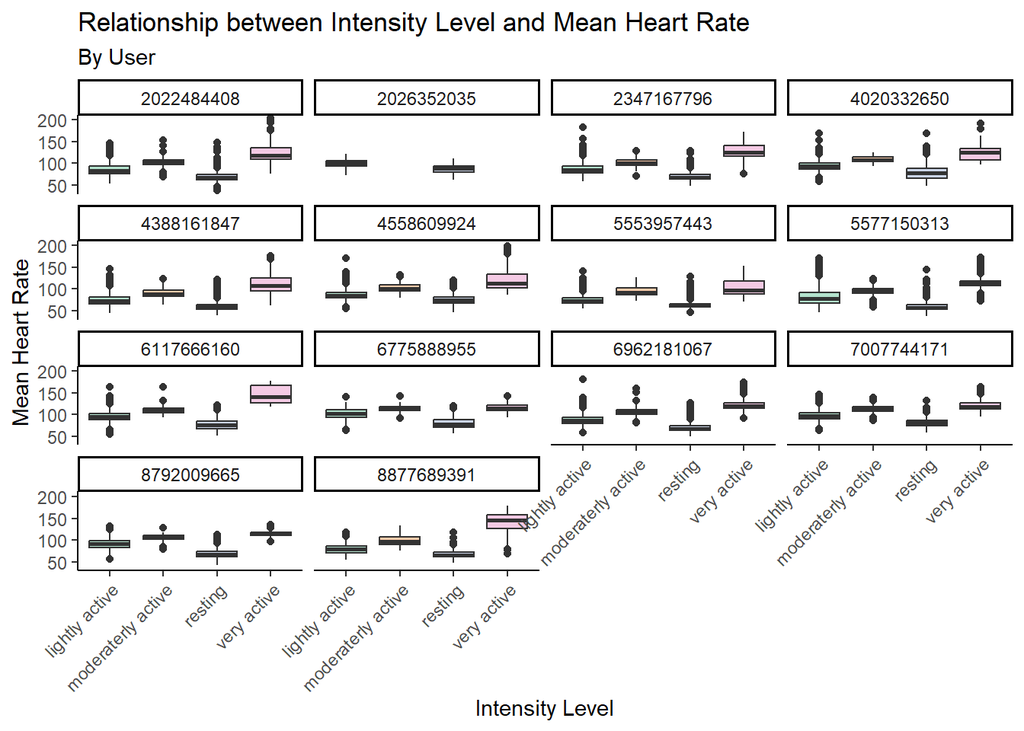

```r
## by users

ggplot(merged_heartrate_intensity, aes(x = IntensityLevel,
                                       y = mean_heartrate,
                                       fill = IntensityLevel)) +
  geom_boxplot() +
  scale_fill_brewer(palette = "Pastel2") +
  labs(title = "Relationship between Intensity Level and Mean Heart Rate",
       subtitle = "By User",
       x = "Intensity Level",
       y = "Mean Heart Rate") +
  theme_classic()+
  facet_wrap(~Id) +
  theme(axis.text.x = element_text(angle = 45, hjust = 1)) +
  theme(legend.position = "none")
```

## Analysis of Weight Data and BMI

#### BMI Categories by User

```r
## Data categorization

number_of_each_BMI_type <- average_BMI_individual %>%
  group_by(type) %>%#
  summarise(BMI_type_counts = n(),
            .groups = "drop")

length (average_BMI_individual$Id)
```

```
## [1] 8
```

```r
head(number_of_each_BMI_type)
```

```
## # A tibble: 3 × 2
##   type          BMI_type_counts
##   <chr>                   <int>
## 1 healthyweight               3
## 2 obese                       1
## 3 overweight                  4
```

##### Bar chart for BMI classification

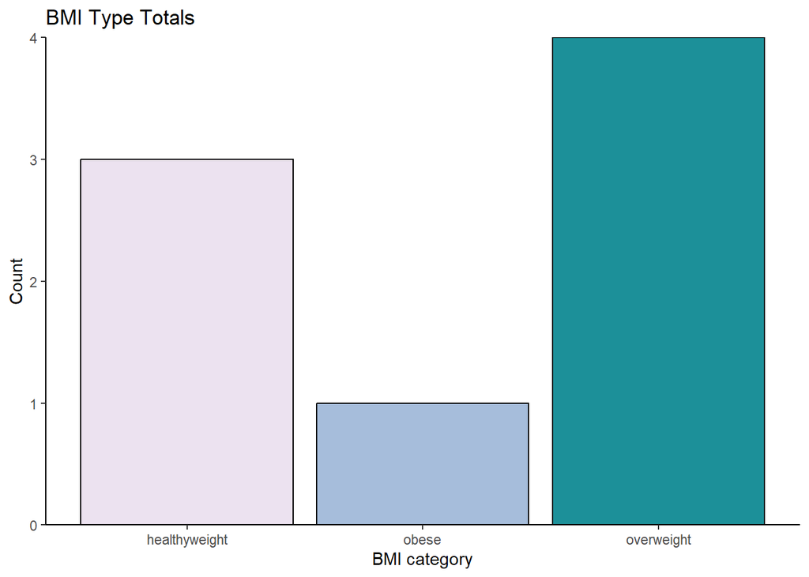

```r
ggplot(number_of_each_BMI_type, aes(x = type,
                                    y = BMI_type_counts,
                                    fill = type)) +
  geom_bar(stat = "identity",
           position = "dodge",
           color = "black") +
  scale_fill_brewer(palette = "PuBuGn", 3) +
  scale_y_continuous(expand = expansion(mult = 0)) +
  labs(title = "BMI Type Totals",
       x = "BMI category",
       y = "Count") +
  theme_classic() +
  theme(legend.position = "none")
```

#### Comparing activities based on BMI

```r
filtered_BMI_data <- average_BMI_individual %>%
  left_join(daily_activity_summary_average,
            by = "Id") %>%
  drop_na()

glimpse(filtered_BMI_data)
```

```
## Rows: 8
## Columns: 10
## $ Id                         <dbl> 1503960366, 1927972279, 2873212765, 4319703…
## $ AverageBMI                 <dbl> 22.65000, 47.54000, 21.57000, 27.41500, 27.…
## $ type                       <chr> "healthyweight", "obese", "healthyweight", …
## $ average_distance           <dbl> 8.070000, 1.157059, 5.101613, 4.882000, 5.0…
## $ average_active_distance    <dbl> 8.065667, 1.156471, 5.095806, 4.700667, 5.0…
## $ average_sedentary_distance <dbl> 0.000000000, 0.000000000, 0.005161290, 0.00…
## $ average_active_minutes     <dbl> 287.06667, 74.17647, 328.22581, 252.83333, …
## $ average_sedentary_minutes  <dbl> 828.4333, 1244.3529, 1097.1935, 712.3333, 1…
## $ average_calories           <dbl> 1876.967, 2303.059, 1916.968, 2035.100, 203…
## $ average_steps              <dbl> 12520.633, 1670.588, 7555.774, 7252.700, 76…
```

```r
head(filtered_BMI_data)
```

```
## # A tibble: 6 × 10
##           Id AverageBMI type          average_distance average_active_distance
##        <dbl>      <dbl> <chr>                    <dbl>                   <dbl>
## 1 1503960366       22.6 healthyweight             8.07                    8.07
## 2 1927972279       47.5 obese                     1.16                    1.16
## 3 2873212765       21.6 healthyweight             5.10                    5.10
## 4 4319703577       27.4 overweight                4.88                    4.70
## 5 4558609924       27.2 overweight                5.08                    5.08
## 6 5577150313       28   overweight                6.66                    6.64
## # ℹ 5 more variables: average_sedentary_distance <dbl>,
## #   average_active_minutes <dbl>, average_sedentary_minutes <dbl>,
## #   average_calories <dbl>, average_steps <dbl>
```

##### Boxplots for visualization

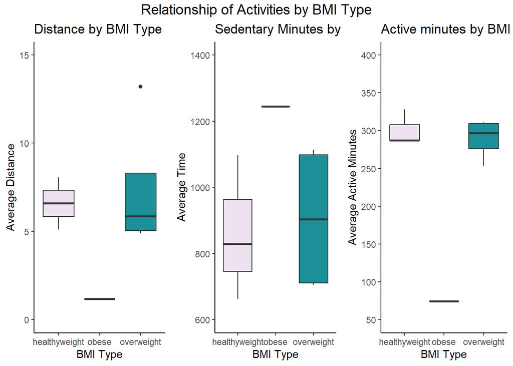

```r
bp1 <- ggplot(filtered_BMI_data, aes(x = type,
                              y = average_distance,
                              fill = type)) +
  geom_boxplot() +
  labs(title = "Distance by BMI Type",
       x = "BMI Type",
       y = "Average Distance") +
  scale_fill_brewer(palette = "PuBuGn", 3) +
  scale_y_continuous(limits = c(0, 15),
                     breaks = seq(0, 15, 5)) +
  theme_classic() +
  theme(legend.position = "none")

bp2 <- ggplot(filtered_BMI_data, aes(x = type,
                              y = average_sedentary_minutes,
                              fill = type)) +
  geom_boxplot() +
  labs(title = "Sedentary Minutes by BMI Type",
       x = "BMI Type",
       y = "Average Time") +
  scale_fill_brewer(palette = "PuBuGn", 3) +
  scale_y_continuous(limits = c(600, 1400),
                     breaks = seq(600,1400, 200)) +
  theme_classic() +
  theme(legend.position = "none")

bp3 <- ggplot(filtered_BMI_data, aes(x = type,
                              y = average_active_minutes,
                              fill = type)) +
  geom_boxplot() +
  scale_fill_brewer(palette = "PuBuGn", 3) +
  labs(title = "Active minutes by BMI Type",
       x = "BMI Type",
       y = "Average Active Minutes") +
  scale_y_continuous(limits = c(50,400),
                     breaks = seq(50,400, 50)) +
  theme_classic() +
  theme(legend.position = "none")

weight_figure <- ggarrange(bp1, bp2, bp3,
                           ncol = 3)
annotate_figure(weight_figure,
                top = text_grob("Relationship of Activities by BMI Type", size = 14))
```

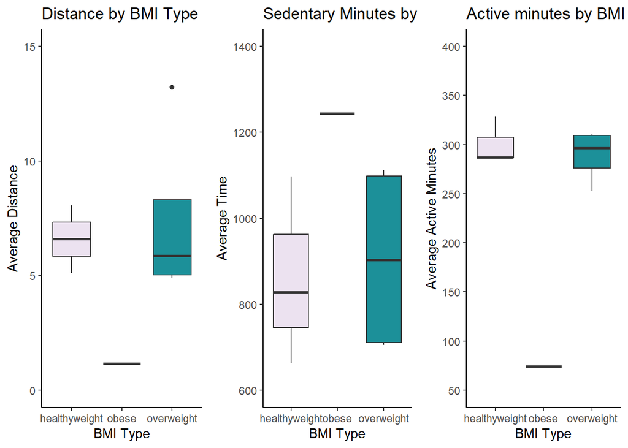

```r
print(weight_figure)
```

#### BMI and Sleep duration

```r
average_sleep_individual <- sleep_day_transformed %>%
  group_by(Id) %>%
  summarise(AverageSleepByDay = mean(TotalMinutesAsleep,
                                     na.rm = TRUE),
            .groups="drop")

sleep_weight_merged <- average_BMI_individual %>%
  left_join(average_sleep_individual,by="Id") %>%
  drop_na()

glimpse(sleep_weight_merged)
```

```
## Rows: 6
## Columns: 4
## $ Id                <dbl> 1503960366, 1927972279, 4319703577, 4558609924, 5577…
## $ AverageBMI        <dbl> 22.650, 47.540, 27.415, 27.214, 28.000, 24.028
## $ type              <chr> "healthyweight", "obese", "overweight", "overweight"…
## $ AverageSleepByDay <dbl> 360.2800, 417.0000, 476.6538, 127.6000, 432.0000, 44…
```

```r
head(sleep_weight_merged)
```

```
## # A tibble: 6 × 4
##           Id AverageBMI type          AverageSleepByDay
##        <dbl>      <dbl> <chr>                     <dbl>
## 1 1503960366       22.6 healthyweight              360.
## 2 1927972279       47.5 obese                      417
## 3 4319703577       27.4 overweight                 477.
## 4 4558609924       27.2 overweight                 128.
## 5 5577150313       28   overweight                 432
## 6 6962181067       24.0 healthyweight              448
```

##### Boxplot for visualization

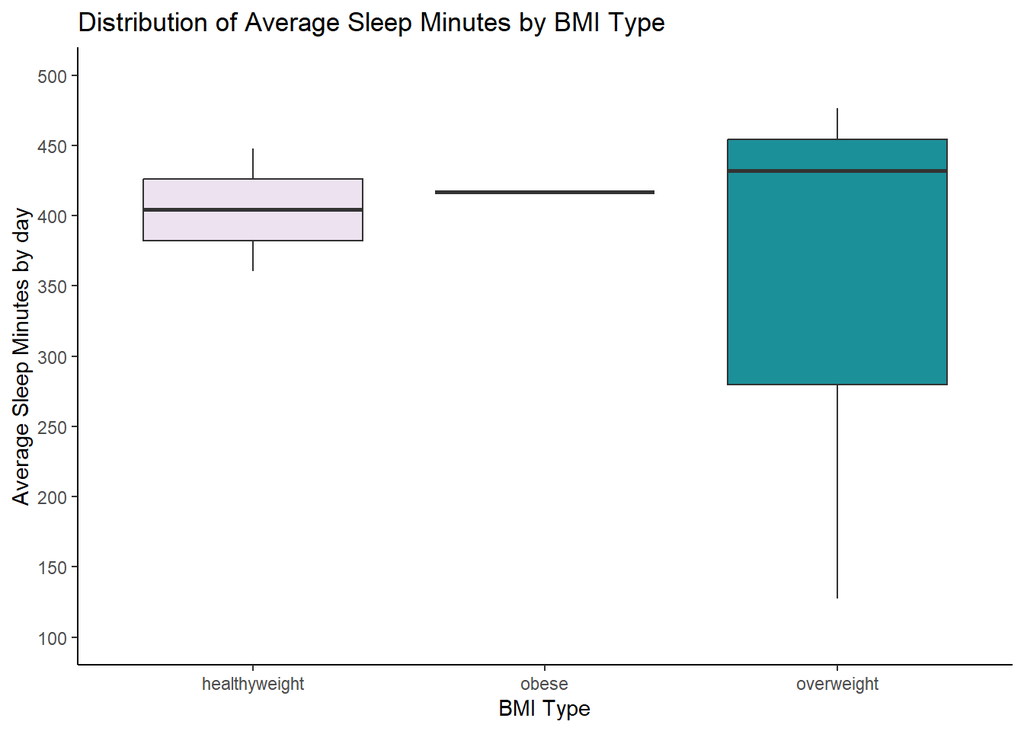

```r
ggplot(sleep_weight_merged, aes(x = type,
                                y = AverageSleepByDay,
                                fill = type)) +
  geom_boxplot() +
  scale_fill_brewer(palette = "PuBuGn", 3) +
  scale_y_continuous(limits = c(100,500),
                     breaks = seq(100, 500, 50)) +
  labs(title = "Distribution of Average Sleep Minutes by BMI Type",
       x = "BMI Type",
       y = "Average Sleep Minutes by day") +
  theme_classic() +
  theme(legend.position = "none")
```

#### BMI and Heartrate

```r
heartrate_day_average <- heartrate_day %>%
  group_by(Id) %>%
  summarise(mean_heartrate = mean(mean_heartrate_day),
           max_heartrate  =mean(max_heartrate_day),
           min_heartrate = mean(min_heartrate_day)) %>%
  ungroup()
head(heartrate_day_average)
```

```
## # A tibble: 6 × 4
##           Id mean_heartrate max_heartrate min_heartrate
##        <dbl>          <dbl>         <dbl>         <dbl>
## 1 2022484408           80.1          147.          51.6
## 2 2026352035           87.6          112.          68.2
## 3 2347167796           76.4          149.          53.6
## 4 4020332650           87.0          135.          56.8
## 5 4388161847           66.1          139.          44.4
## 6 4558609924           81.6          132.          54.9
```

```r
heartrate_weight_merged <- average_BMI_individual %>%
  left_join(heartrate_day_average,
            by="Id") %>%
  drop_na()

glimpse(heartrate_weight_merged)
```

```
## Rows: 4
## Columns: 6
## $ Id             <dbl> 4558609924, 5577150313, 6962181067, 8877689391
## $ AverageBMI     <dbl> 27.21400, 28.00000, 24.02800, 25.48708
## $ type           <chr> "overweight", "overweight", "healthyweight", "overweigh…
## $ mean_heartrate <dbl> 81.59983, 68.96059, 77.55010, 82.14210
## $ max_heartrate  <dbl> 131.8387, 147.0357, 143.6774, 157.6129
## $ min_heartrate  <dbl> 54.90323, 42.60714, 54.09677, 50.00000
```

```r
head(heartrate_weight_merged)
```

```
## # A tibble: 4 × 6
##           Id AverageBMI type          mean_heartrate max_heartrate min_heartrate
##        <dbl>      <dbl> <chr>                  <dbl>         <dbl>         <dbl>
## 1 4558609924       27.2 overweight              81.6          132.          54.9
## 2 5577150313       28   overweight              69.0          147.          42.6
## 3 6962181067       24.0 healthyweight           77.6          144.          54.1
## 4 8877689391       25.5 overweight              82.1          158.          50
```

##### Boxplots for visualization

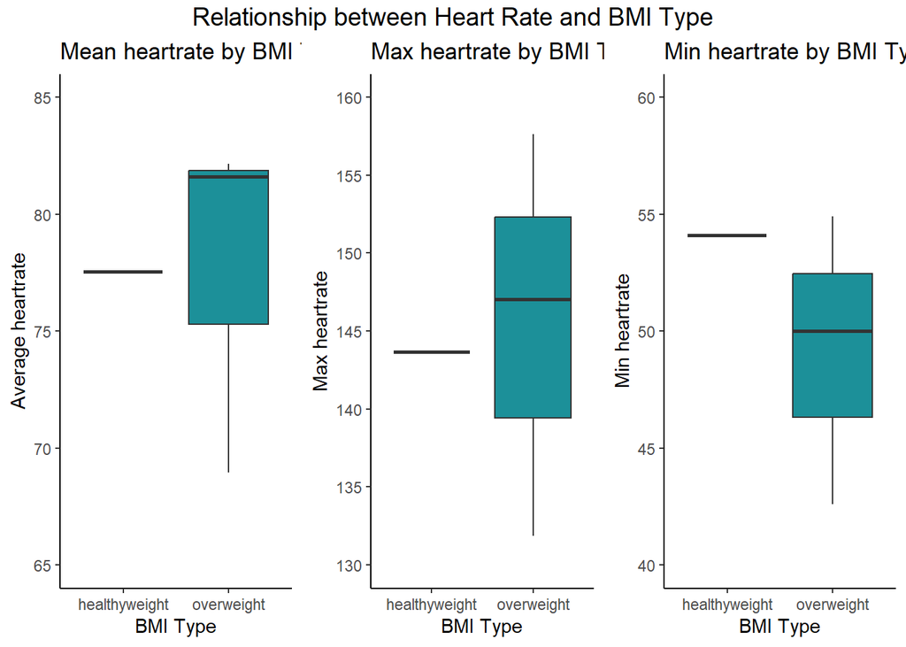

```r
bp4 <- ggplot(heartrate_weight_merged, aes(x = type,
                                    y = mean_heartrate,
                                    fill = type)) +
  geom_boxplot() +
  scale_fill_manual(values = c("#ECE2F0", "#1C9099")) +
  scale_y_continuous(limits = c(65, 85),
                     breaks = seq(65, 85, 5)) +
  labs(title = "Mean heartrate by BMI Type",
       x = "BMI Type",
       y = "Average heartrate") +
  theme_classic()  +
  theme(legend.position = "none")

bp5 <- ggplot(heartrate_weight_merged, aes(x = type,
                                    y = max_heartrate,
                                    fill = type)) +
  geom_boxplot() +
  scale_fill_manual(values = c("#ECE2F0", "#1C9099")) +
  scale_y_continuous(limits = c(130, 160),
                     breaks = seq(130, 160, 5)) +
  labs(title = "Max heartrate by BMI Type",
       x = "BMI Type",
       y = "Max heartrate") +
  theme_classic()  +
  theme(legend.position = "none")

bp6 <- ggplot(heartrate_weight_merged, aes(x = type,
                                    y = min_heartrate,
                                    fill = type)) +
  geom_boxplot() +
  scale_fill_manual(values = c("#ECE2F0", "#1C9099")) +
  scale_y_continuous(limits = c(40, 60),
                     breaks = seq(40, 60, 5)) +
  labs(title = "Min heartrate by BMI Type",
       x = "BMI Type",
       y = "Min heartrate") +
  theme_classic()  +
  theme(legend.position = "none")

weight_figure_2 <- ggarrange(bp4, bp5, bp6,
                           ncol = 3)
annotate_figure(weight_figure_2,
                top = text_grob("Relationship between Heart Rate and BMI Type", size = 14))
```

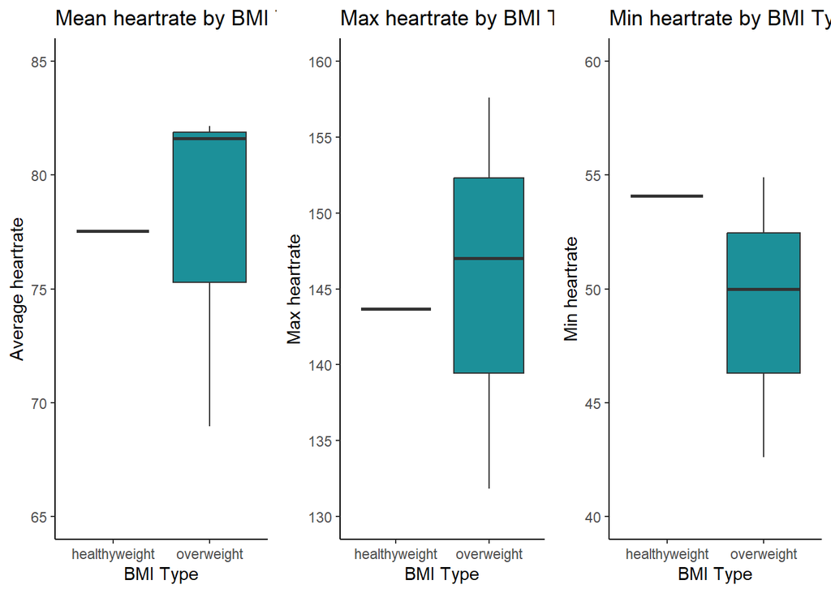

```r
print(weight_figure_2)
```